# Assignment3_Data622

Mubashira Qari

2025-10-26

# 1 Bank Marketing Dataset Variables

The dataset’s main purpose is to predict whether a bank client will subscribe to a term deposit (`y = yes/no`) after a marketing campaign. Each variable provides information that may help explain or predict that outcome.

## 1.1 Client Information (Who the Customer Is)

- **age (numeric)**
  - *Recording:* Client’s age in years.
  - *Purpose:* Age often influences financial decisions (e.g., younger clients may avoid long-term deposits, older clients may be more interested in safe investments).
- **job (categorical)**
  - *Recording:* Type of job (e.g., admin, blue-collar, technician).
  - *Purpose:* Occupation reflects income stability and financial behavior.
- **marital (categorical)**
  - *Recording:* Marital status (single, married, divorced/widowed).
  - *Purpose:* Family responsibilities affect savings and investment behavior.
- **education (categorical)**
  - *Recording:* Highest education level completed.
  - *Purpose:* Education level may indicate financial literacy and likelihood to invest.
- **default (categorical)**
  - *Recording:* Whether client has credit in default (“yes”, “no”, “unknown”).
  - *Purpose:* Default history reflects financial risk and trustworthiness.
- **housing (categorical)**
  - *Recording:* Whether client has a housing loan.
  - *Purpose:* Mortgage holders may have less disposable income for deposits.
- **loan (categorical)**
  - *Recording:* Whether client has a personal loan.
  - *Purpose:* Personal loans indicate financial obligations that may reduce likelihood of subscribing.

## 1.2 Last Contact Information (How They Were Reached)

- **contact (categorical)**
  - *Recording:* Communication type (“cellular” or “telephone”).
  - *Purpose:* Some contact methods are more effective than others.
- **month (categorical)**
  - *Recording:* Month of the last contact.
  - *Purpose:* Seasonal effects — campaign success may vary across the year.
- **day_of_week (categorical)**
  - *Recording:* Day of the week client was contacted.
  - *Purpose:* Some days may be better for reaching clients (e.g., midweek vs. Monday).
- **duration (numeric)**
  - *Recording:* Call duration in seconds.
  - *Purpose:* Longer conversations often mean higher engagement.
  - *Note:* Duration is only known after the call, so it cannot be used in real prediction models.

## 1.3 Campaign History (Past Interactions)

- **campaign (numeric)**
  - *Recording:* Number of contacts during this campaign (including the last one).
  - *Purpose:* Too many contacts may annoy clients, reducing success.
- **pdays (numeric)**
  - *Recording:* Days since last contact from a previous campaign (999 = never contacted).
  - *Purpose:* Recency matters; recently contacted clients may behave differently.
- **previous (numeric)**
  - *Recording:* Number of contacts before this campaign.
  - *Purpose:* Reflects persistence of bank marketing; may affect likelihood of success.
- **poutcome (categorical)**
  - *Recording:* Outcome of the previous campaign (“success”, “failure”, “nonexistent”).
  - *Purpose:* Past behavior often predicts future responses.

## 1.4 Economic Context (Overall Environment)

- **emp.var.rate (numeric)**
  - *Recording:* Employment variation rate (quarterly).
  - *Purpose:* Measures labor market changes — people may invest more when jobs are stable.
- **cons.price.idx (numeric)**
  - *Recording:* Consumer Price Index (monthly).
  - *Purpose:* Inflation affects purchasing power and saving behavior.
- **cons.conf.idx (numeric)**
  - *Recording:* Consumer Confidence Index (monthly).
  - *Purpose:* High confidence = more willingness to invest, low confidence = caution.
- **euribor3m (numeric)**
  - *Recording:* Euribor 3-month interest rate.
  - *Purpose:* Competes with deposit rates — higher Euribor may reduce deposit attractiveness.
- **nr.employed (numeric)**
  - *Recording:* Number of employees (quarterly labor market indicator).
  - *Purpose:* Reflects macroeconomic health; higher employment often correlates with more savings.

## 1.5 Target Variable

- **y (binary: “yes” / “no”)**
  - *Recording:* Whether the client subscribed to a term deposit.
  - *Purpose:* This is the outcome to predict.

## 1.6 **PART I: Exploratory Data Analysis (EDA)**

```r
# Load Libraries

library(dplyr)
library(tidyverse)
library(psych)
library(ggplot2)
library(plotly)
library(tidyr)
library(corrplot)
library(ggpubr)
library(naniar)     # for missing value visualization
library(DataExplorer) # optional: automated EDA
library(forcats)
library(caret)
library(recipes)
library(themis)
library(smotefamily)
```

```r
# Load Dataset

url <- "https://raw.githubusercontent.com/uzmabb182/Data_622/refs/heads/main/Assignment_1_EDA/bank-additional-full.csv"
bank_additional_df <- read.csv2(url, stringsAsFactors = FALSE)
head(bank_additional_df)
```

```
##   age       job marital   education default housing loan   contact month
## 1  56 housemaid married    basic.4y      no      no   no telephone   may
## 2  57  services married high.school unknown      no   no telephone   may
## 3  37  services married high.school      no     yes   no telephone   may
## 4  40    admin. married    basic.6y      no      no   no telephone   may
## 5  56  services married high.school      no      no  yes telephone   may
## 6  45  services married    basic.9y unknown      no   no telephone   may
##   day_of_week duration campaign pdays previous    poutcome emp.var.rate
## 1         mon      261        1   999        0 nonexistent          1.1
## 2         mon      149        1   999        0 nonexistent          1.1
## 3         mon      226        1   999        0 nonexistent          1.1
## 4         mon      151        1   999        0 nonexistent          1.1
## 5         mon      307        1   999        0 nonexistent          1.1
## 6         mon      198        1   999        0 nonexistent          1.1
##   cons.price.idx cons.conf.idx euribor3m nr.employed  y
## 1         93.994         -36.4     4.857        5191 no
## 2         93.994         -36.4     4.857        5191 no
## 3         93.994         -36.4     4.857        5191 no
## 4         93.994         -36.4     4.857        5191 no
## 5         93.994         -36.4     4.857        5191 no
## 6         93.994         -36.4     4.857        5191 no
```

```r
# Basic structure
str(bank_additional_df)
```

```
## 'data.frame':    41188 obs. of  21 variables:
##  $ age           : int  56 57 37 40 56 45 59 41 24 25 ...
##  $ job           : chr  "housemaid" "services" "services" "admin." ...
##  $ marital       : chr  "married" "married" "married" "married" ...
##  $ education     : chr  "basic.4y" "high.school" "high.school" "basic.6y" ...
##  $ default       : chr  "no" "unknown" "no" "no" ...
##  $ housing       : chr  "no" "no" "yes" "no" ...
##  $ loan          : chr  "no" "no" "no" "no" ...
##  $ contact       : chr  "telephone" "telephone" "telephone" "telephone" ...
##  $ month         : chr  "may" "may" "may" "may" ...
##  $ day_of_week   : chr  "mon" "mon" "mon" "mon" ...
##  $ duration      : int  261 149 226 151 307 198 139 217 380 50 ...
##  $ campaign      : int  1 1 1 1 1 1 1 1 1 1 ...
##  $ pdays         : int  999 999 999 999 999 999 999 999 999 999 ...
##  $ previous      : int  0 0 0 0 0 0 0 0 0 0 ...
##  $ poutcome      : chr  "nonexistent" "nonexistent" "nonexistent" "nonexistent" ...
##  $ emp.var.rate  : chr  "1.1" "1.1" "1.1" "1.1" ...
##  $ cons.price.idx: chr  "93.994" "93.994" "93.994" "93.994" ...
##  $ cons.conf.idx : chr  "-36.4" "-36.4" "-36.4" "-36.4" ...
##  $ euribor3m     : chr  "4.857" "4.857" "4.857" "4.857" ...
##  $ nr.employed   : chr  "5191" "5191" "5191" "5191" ...
##  $ y             : chr  "no" "no" "no" "no" ...
```

```r
# Dimensions
dim(bank_additional_df)   # rows, columns
```

```
## [1] 41188    21
```

```r
nrow(bank_additional_df)  # number of rows
```

```
## [1] 41188
```

```r
ncol(bank_additional_df)  # number of columns
```

```
## [1] 21
```

```r
# Column names
names(bank_additional_df)
```

```
##  [1] "age"            "job"            "marital"        "education"
##  [5] "default"        "housing"        "loan"           "contact"
##  [9] "month"          "day_of_week"    "duration"       "campaign"
## [13] "pdays"          "previous"       "poutcome"       "emp.var.rate"
## [17] "cons.price.idx" "cons.conf.idx"  "euribor3m"      "nr.employed"
## [21] "y"
```

```r
# Summary statistics for all variables
summary(bank_additional_df)
```

```
##       age            job              marital           education
##  Min.   :17.00   Length:41188       Length:41188       Length:41188
##  1st Qu.:32.00   Class :character   Class :character   Class :character
##  Median :38.00   Mode  :character   Mode  :character   Mode  :character
##  Mean   :40.02
##  3rd Qu.:47.00
##  Max.   :98.00
##    default            housing              loan             contact
##  Length:41188       Length:41188       Length:41188       Length:41188
##  Class :character   Class :character   Class :character   Class :character
##  Mode  :character   Mode  :character   Mode  :character   Mode  :character
##
##
##
##     month           day_of_week           duration         campaign
##  Length:41188       Length:41188       Min.   :   0.0   Min.   : 1.000
##  Class :character   Class :character   1st Qu.: 102.0   1st Qu.: 1.000
##  Mode  :character   Mode  :character   Median : 180.0   Median : 2.000
##                                        Mean   : 258.3   Mean   : 2.568
##                                        3rd Qu.: 319.0   3rd Qu.: 3.000
##                                        Max.   :4918.0   Max.   :56.000
##      pdays          previous       poutcome         emp.var.rate
##  Min.   :  0.0   Min.   :0.000   Length:41188       Length:41188
##  1st Qu.:999.0   1st Qu.:0.000   Class :character   Class :character
##  Median :999.0   Median :0.000   Mode  :character   Mode  :character
##  Mean   :962.5   Mean   :0.173
##  3rd Qu.:999.0   3rd Qu.:0.000
##  Max.   :999.0   Max.   :7.000
##  cons.price.idx     cons.conf.idx       euribor3m         nr.employed
##  Length:41188       Length:41188       Length:41188       Length:41188
##  Class :character   Class :character   Class :character   Class :character
##  Mode  :character   Mode  :character   Mode  :character   Mode  :character
##
##
##
##       y
##  Length:41188
##  Class :character
##  Mode  :character
##
##
##
```

Are there any missing values and how significant are they?

```r
# First and last few records
head(bank_additional_df, 10)
```

```
##    age         job marital           education default housing loan   contact
## 1   56   housemaid married            basic.4y      no      no   no telephone
## 2   57    services married         high.school unknown      no   no telephone
## 3   37    services married         high.school      no     yes   no telephone
## 4   40      admin. married            basic.6y      no      no   no telephone
## 5   56    services married         high.school      no      no  yes telephone
## 6   45    services married            basic.9y unknown      no   no telephone
## 7   59      admin. married professional.course      no      no   no telephone
## 8   41 blue-collar married             unknown unknown      no   no telephone
## 9   24  technician  single professional.course      no     yes   no telephone
## 10  25    services  single         high.school      no     yes   no telephone
##    month day_of_week duration campaign pdays previous    poutcome emp.var.rate
## 1    may         mon      261        1   999        0 nonexistent          1.1
## 2    may         mon      149        1   999        0 nonexistent          1.1
## 3    may         mon      226        1   999        0 nonexistent          1.1
```

[output cut: 18 more lines]

```r
tail(bank_additional_df, 10)
```

```
##       age         job  marital           education default housing loan
## 41179  62     retired  married   university.degree      no      no   no
## 41180  64     retired divorced professional.course      no     yes   no
## 41181  36      admin.  married   university.degree      no      no   no
## 41182  37      admin.  married   university.degree      no     yes   no
## 41183  29  unemployed   single            basic.4y      no     yes   no
## 41184  73     retired  married professional.course      no     yes   no
## 41185  46 blue-collar  married professional.course      no      no   no
## 41186  56     retired  married   university.degree      no     yes   no
## 41187  44  technician  married professional.course      no      no   no
## 41188  74     retired  married professional.course      no     yes   no
##        contact month day_of_week duration campaign pdays previous    poutcome
## 41179 cellular   nov         thu      483        2     6        3     success
## 41180 cellular   nov         fri      151        3   999        0 nonexistent
## 41181 cellular   nov         fri      254        2   999        0 nonexistent
```

[output cut: 18 more lines]

```r
# Missing values per column
missing_summary <- bank_additional_df %>%
  summarise(across(everything(), ~ sum(is.na(.)))) %>%
  pivot_longer(cols = everything(), names_to = "Variable", values_to = "Missing_Count") %>%
  mutate(Missing_Percent = round(Missing_Count / nrow(bank_additional_df) * 100, 2)) %>%
  arrange(desc(Missing_Count))

missing_summary
```

```
## # A tibble: 21 × 3
##    Variable    Missing_Count Missing_Percent
##    <chr>               <int>           <dbl>
##  1 age                     0               0
##  2 job                     0               0
##  3 marital                 0               0
##  4 education               0               0
##  5 default                 0               0
##  6 housing                 0               0
##  7 loan                    0               0
##  8 contact                 0               0
##  9 month                   0               0
## 10 day_of_week             0               0
## # ℹ 11 more rows
```

## 1.7 Are There Missing Values?

The dataset does not contain raw `NA` values, but instead uses **special codes or labels** to represent “missing” or “not applicable.” These are **structural missing values** and must be considered carefully during analysis.

### 1.7.1 Where They Occur

- **Categorical variables with `"unknown"`**
  - *default:* `"unknown"` is very common (many clients do not disclose credit default history).
  - *education:* includes an `"unknown"` category (~5% of records).
  - *job:* contains a small number of `"unknown"` entries.
- **Special numeric code – `pdays = 999`**
  - Indicates the client was **not previously contacted**.
  - Dominates the column (~96% of rows).
  - Not truly “missing,” but a **placeholder code** that should be treated as its own category.

### 1.7.2 Significance of Missingness

- **default = “unknown”:** Very significant because it covers a large fraction of the data. Dropping it would result in too much information loss, so it should be treated as its own level (“missing info”).
- **education = “unknown”:** Smaller but still relevant; may need grouping with other low-frequency categories.
- **job = “unknown”:** Rare and not very impactful, but still worth encoding properly.
- **pdays = 999:** Extremely significant since it applies to almost all clients. If not handled correctly, it can distort model training.

### 1.7.3 Final Answer

Yes, there are missing values, but they appear as **coded placeholders** rather than raw `NA`:

- `"unknown"` in categorical variables (*default, education, job*).
- `pdays = 999` meaning “not previously contacted.”

These placeholders are highly significant because they cover a large portion of the dataset (especially *pdays* and *default*). Instead of dropping them, they should be **treated as meaningful categories or carefully recoded** for modeling.

```r
# Unique values in categorical variables (factor/character columns)
lapply(bank_additional_df[sapply(bank_additional_df, is.character)], unique)
```

```
## $job
##  [1] "housemaid"     "services"      "admin."        "blue-collar"
##  [5] "technician"    "retired"       "management"    "unemployed"
##  [9] "self-employed" "unknown"       "entrepreneur"  "student"
##
## $marital
## [1] "married"  "single"   "divorced" "unknown"
##
## $education
## [1] "basic.4y"            "high.school"         "basic.6y"
## [4] "basic.9y"            "professional.course" "unknown"
## [7] "university.degree"   "illiterate"
##
## $default
## [1] "no"      "unknown" "yes"
##
## $housing
## [1] "no"      "yes"     "unknown"
##
## $loan
## [1] "no"      "yes"     "unknown"
##
## $contact
## [1] "telephone" "cellular"
##
## $month
##  [1] "may" "jun" "jul" "aug" "oct" "nov" "dec" "mar" "apr" "sep"
##
## $day_of_week
## [1] "mon" "tue" "wed" "thu" "fri"
##
## $poutcome
## [1] "nonexistent" "failure"     "success"
##
## $emp.var.rate
##  [1] "1.1"  "1.4"  "-0.1" "-0.2" "-1.8" "-2.9" "-3.4" "-3"   "-1.7" "-1.1"
##
## $cons.price.idx
##  [1] "93.994" "94.465" "93.918" "93.444" "93.798" "93.2"   "92.756" "92.843"
##  [9] "93.075" "92.893" "92.963" "92.469" "92.201" "92.379" "92.431" "92.649"
```

[output cut: 37 more lines]

```
## [253] "0.732" "0.748" "0.761" "0.767" "0.782" "0.79"  "0.793" "0.802" "0.81"
## [262] "0.822" "0.827" "0.835" "0.84"  "0.846" "0.87"  "0.876" "0.885" "0.889"
## [271] "0.893" "0.896" "0.898" "0.9"   "0.904" "0.905" "0.895" "0.894" "0.891"
## [280] "0.89"  "0.888" "0.886" "0.882" "0.88"  "0.878" "0.877" "0.942" "0.953"
## [289] "0.956" "0.959" "0.965" "0.972" "0.977" "0.982" "0.985" "0.987" "0.993"
## [298] "1"     "1.008" "1.016" "1.025" "1.032" "1.037" "1.043" "1.045" "1.047"
## [307] "1.05"  "1.049" "1.046" "1.041" "1.04"  "1.039" "1.035" "1.03"  "1.031"
## [316] "1.028"
##
## $nr.employed
##  [1] "5191"   "5228.1" "5195.8" "5176.3" "5099.1" "5076.2" "5017.5" "5023.5"
##  [9] "5008.7" "4991.6" "4963.6"
##
## $y
## [1] "no"  "yes"
```

```r
library(dplyr)
library(tidyr)

# Select only character (categorical) columns
categorical_df <- bank_additional_df %>% select(where(is.character))

# Using describe () for summary statsw
describe(categorical_df)
```

```
##                 vars     n   mean    sd median trimmed   mad min max range
## job*               1 41188   4.72  3.59      3    4.48  2.97   1  12    11
## marital*           2 41188   2.17  0.61      2    2.21  0.00   1   4     3
## education*         3 41188   4.75  2.14      4    4.88  2.97   1   8     7
## default*           4 41188   1.21  0.41      1    1.14  0.00   1   3     2
## housing*           5 41188   2.07  0.99      3    2.09  0.00   1   3     2
## loan*              6 41188   1.33  0.72      1    1.16  0.00   1   3     2
## contact*           7 41188   1.37  0.48      1    1.33  0.00   1   2     1
## month*             8 41188   5.23  2.32      5    5.31  2.97   1  10     9
## day_of_week*       9 41188   3.00  1.40      3    3.01  1.48   1   5     4
## poutcome*         10 41188   1.93  0.36      2    2.00  0.00   1   3     2
## emp.var.rate*     11 41188   7.44  2.95      9    7.90  1.48   1  10     9
## cons.price.idx*   12 41188  15.20  5.56     15   15.28  5.93   1  26    25
## cons.conf.idx*    13 41188  15.66  5.98     18   15.98  5.93   1  26    25
## euribor3m*        14 41188 256.63 68.67    288  270.84 29.65   1 316   315
## nr.employed*      15 41188   8.85  2.45      9    9.25  2.97   1  11    10
## y*                16 41188   1.11  0.32      1    1.02  0.00   1   2     1
##                  skew kurtosis   se
## job*             0.45    -1.39 0.02
## marital*        -0.06    -0.34 0.00
## education*      -0.24    -1.21 0.01
## default*         1.44     0.07 0.00
## housing*        -0.14    -1.95 0.00
## loan*            1.82     1.38 0.00
## contact*         0.56    -1.69 0.00
## month*          -0.31    -1.03 0.01
## day_of_week*     0.01    -1.27 0.01
## poutcome*       -0.88     3.98 0.00
## emp.var.rate*   -0.86    -0.50 0.01
## cons.price.idx* -0.29    -0.40 0.03
## cons.conf.idx*  -0.45    -1.07 0.03
## euribor3m*      -1.72     2.56 0.34
## nr.employed*    -1.21     1.05 0.01
## y*               2.45     4.00 0.00
```

What is the overall distribution of each variable?

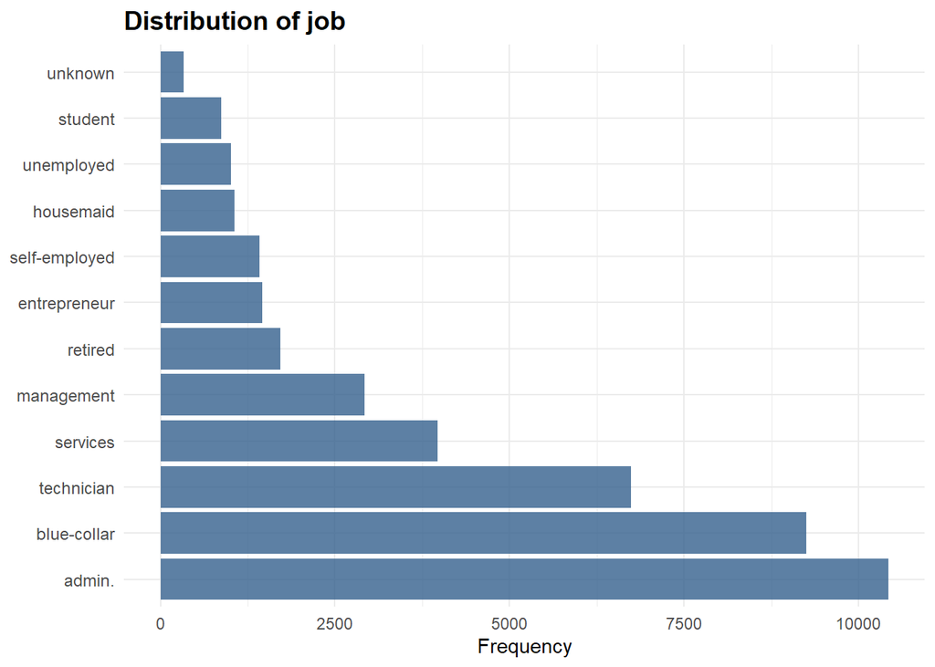

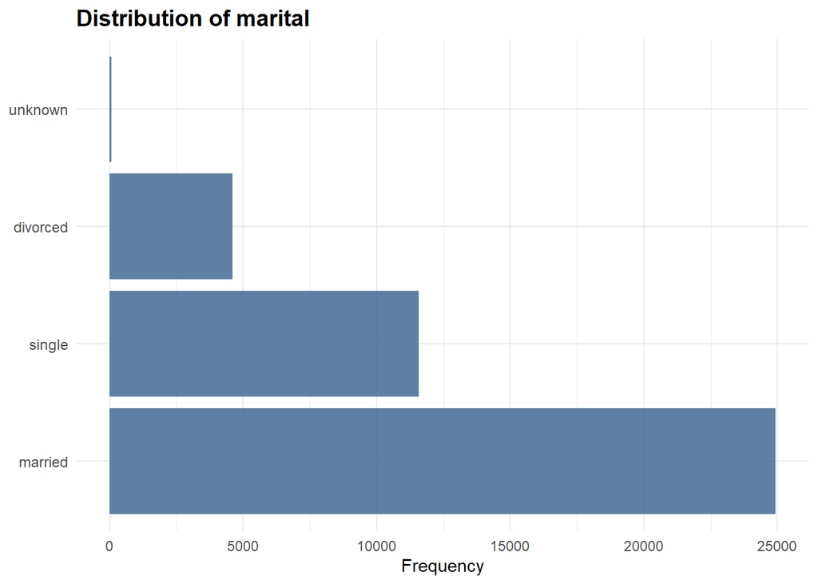

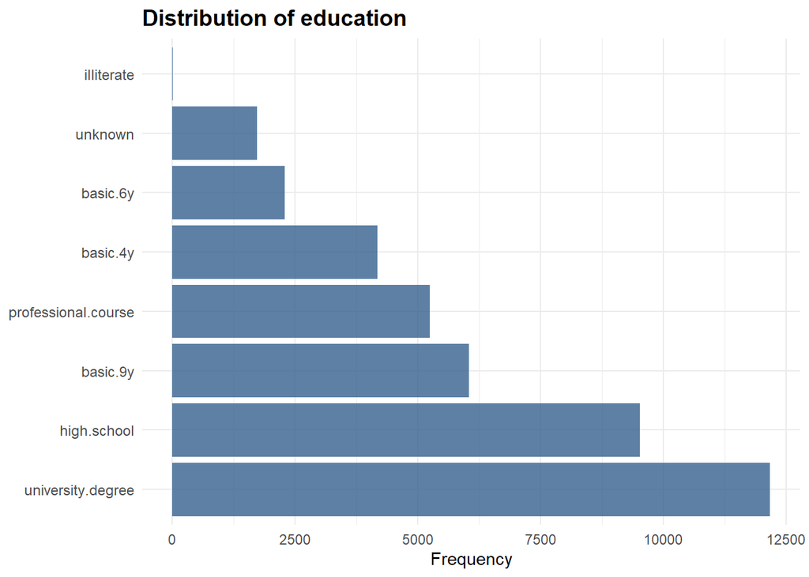

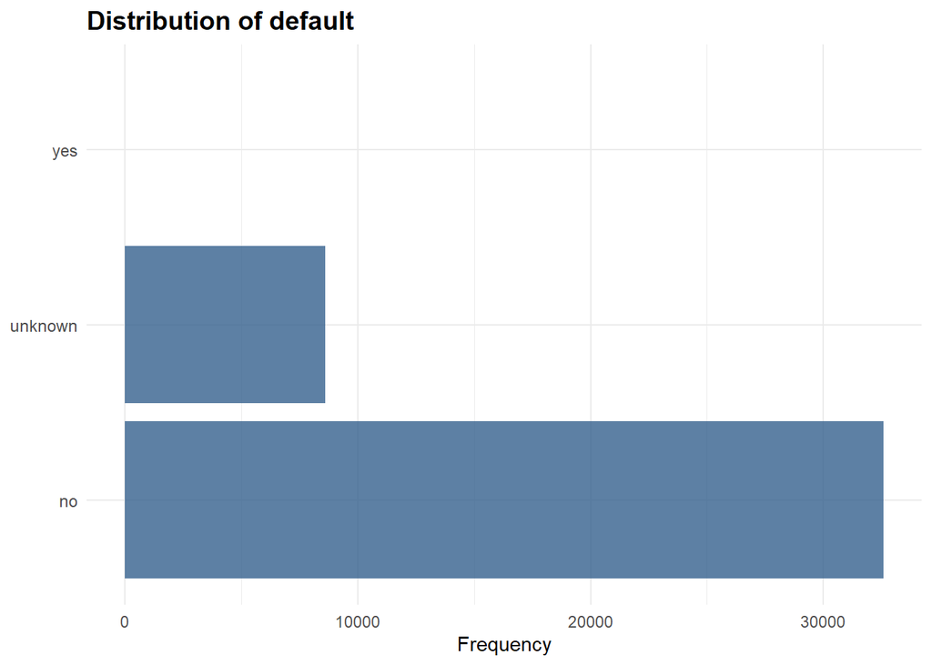

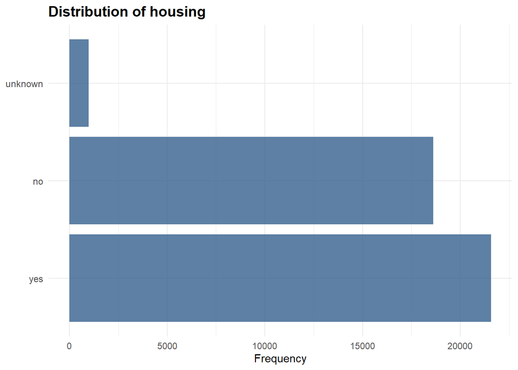

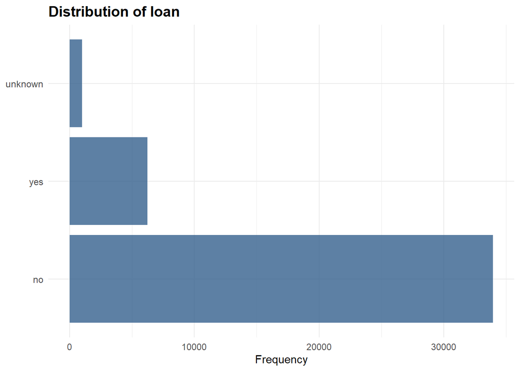

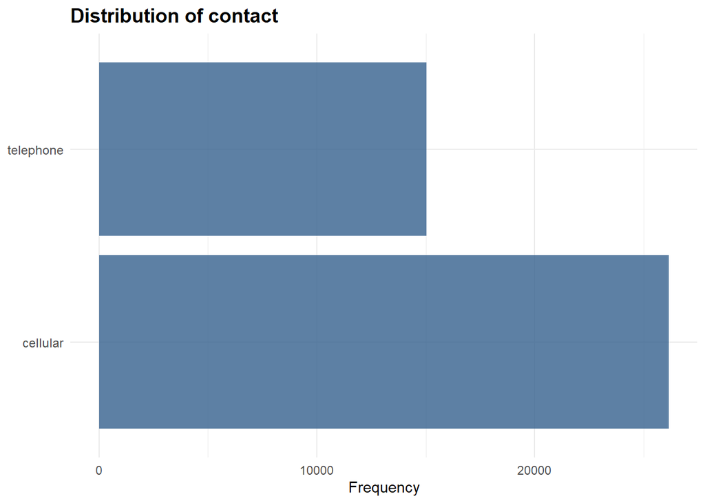

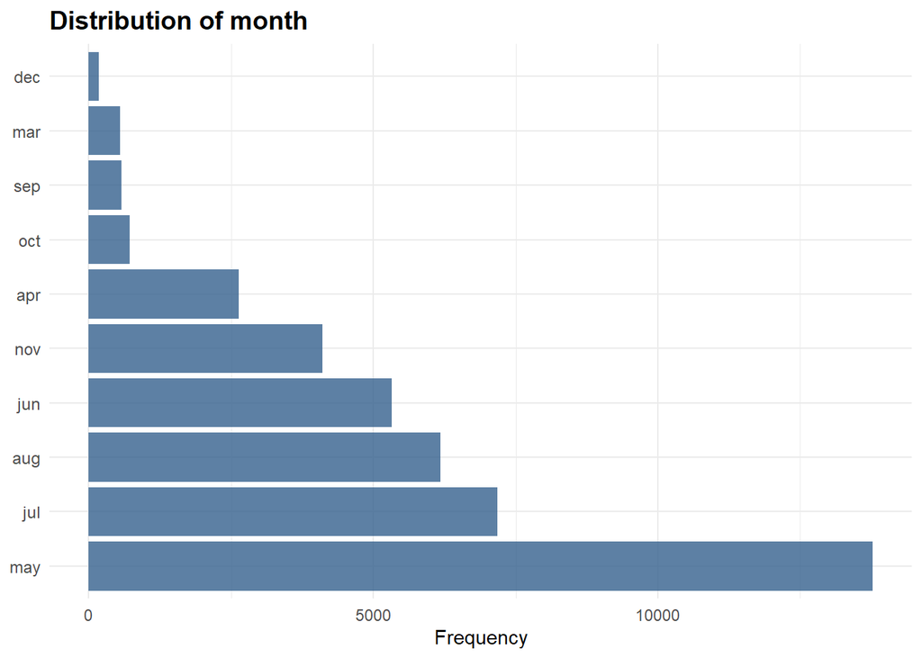

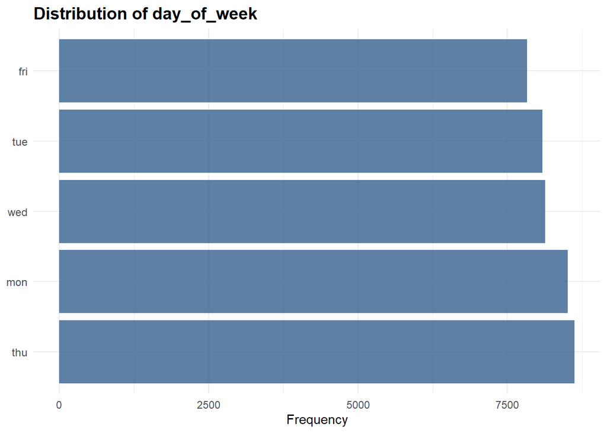

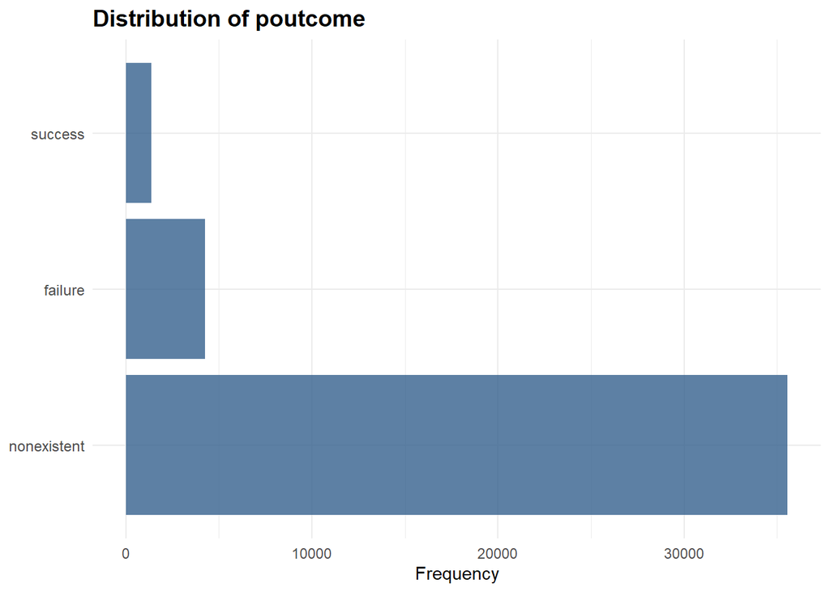

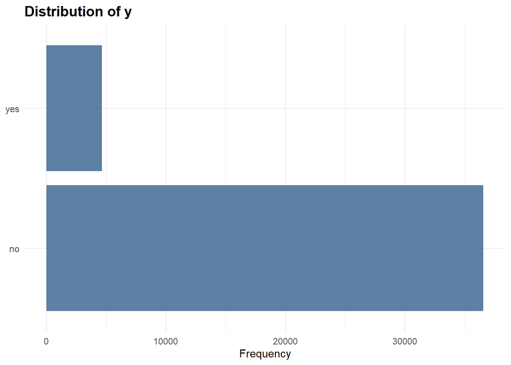

```r
library(ggplot2)
library(dplyr)
library(forcats)
library(viridis)
# Ensure correct types
bank_additional_df <- bank_additional_df %>%
  mutate(
    euribor3m = as.numeric(euribor3m),  # force to numeric
    nr.employed = as.numeric(nr.employed),
    emp.var.rate = as.numeric(emp.var.rate),
    cons.price.idx = as.numeric(cons.price.idx),
    cons.conf.idx = as.numeric(cons.conf.idx)
  )

# Separate categorical and numeric columns
categorical_df <- bank_additional_df %>% select(where(is.character))
numeric_df     <- bank_additional_df %>% select(where(is.numeric))

# --- Plot categorical variables (one by one) ---
for (col in names(categorical_df)) {
  p <- categorical_df %>%
    ggplot(aes(x = fct_infreq(.data[[col]]))) +
    geom_bar(fill = viridis(1, begin = 0.3, end = 0.8), alpha = 0.8) +
    coord_flip() +   # flip for readability
    theme_minimal() +
    theme(
      axis.text.y = element_text(size = 9),
      axis.title.y = element_blank(),
      axis.title.x = element_text(size = 11),
      plot.title = element_text(size = 14, face = "bold")
    ) +
    ylab("Frequency") +
    ggtitle(paste("Distribution of", col))

  print(p)
}
```

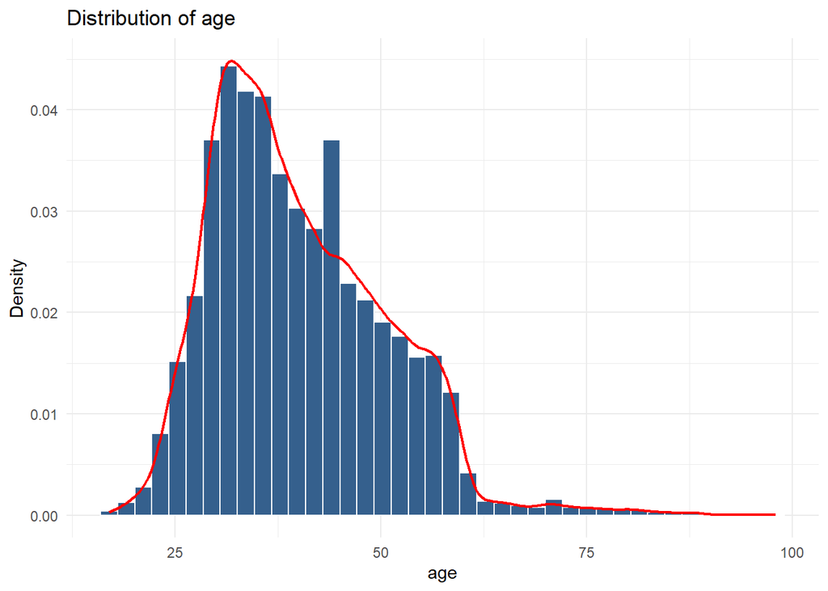

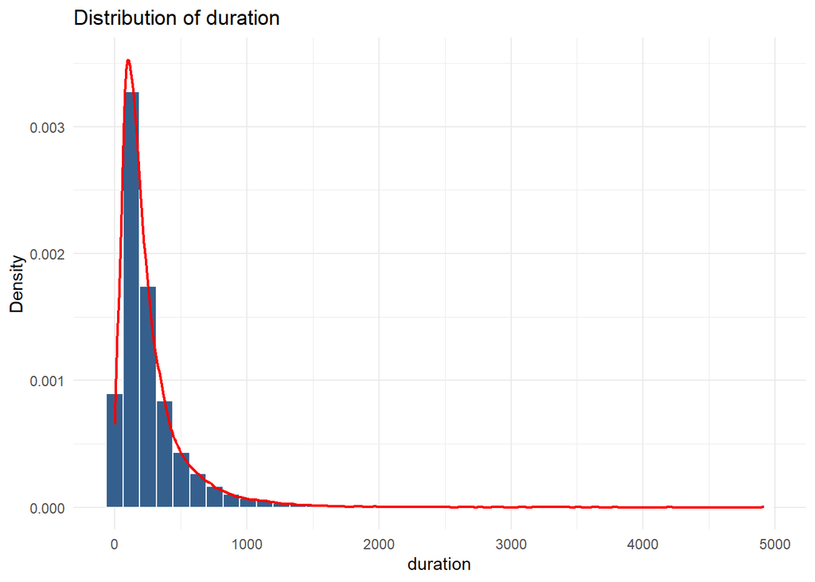

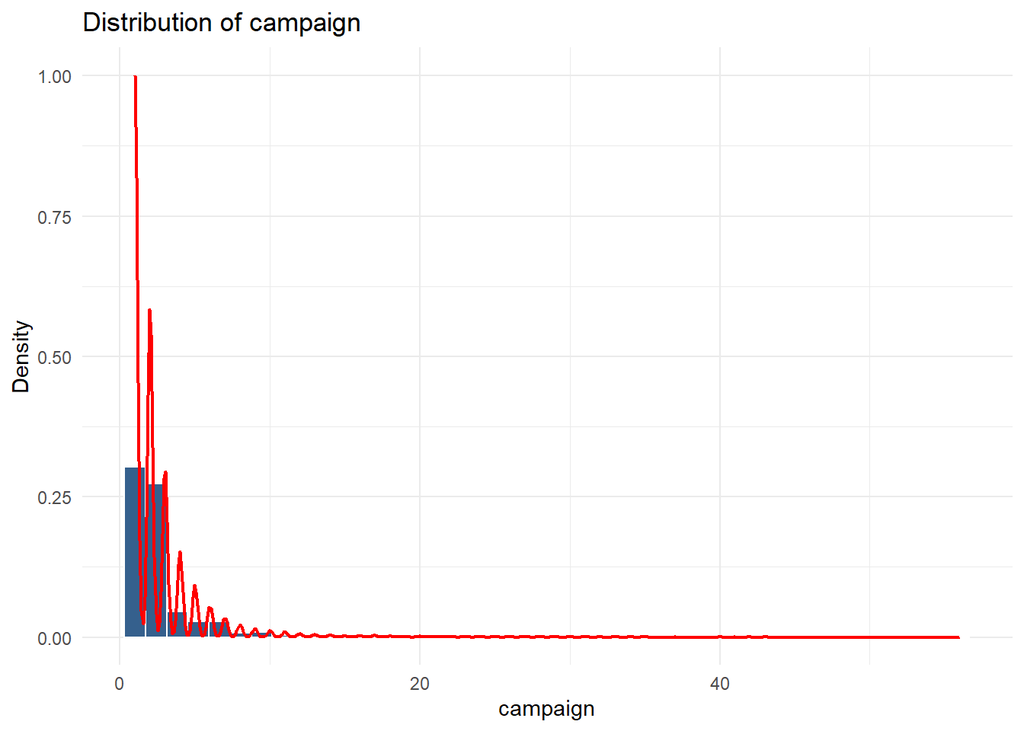

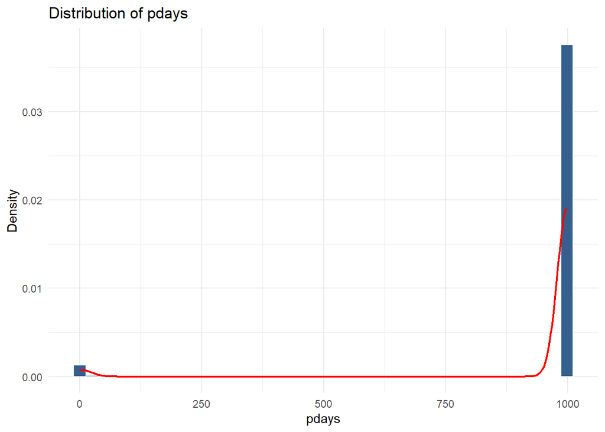

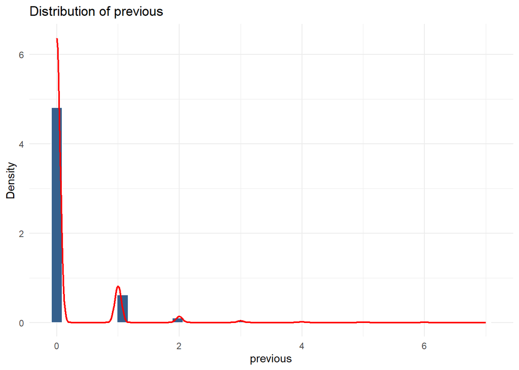

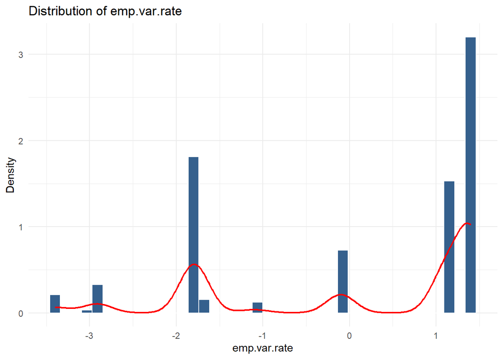

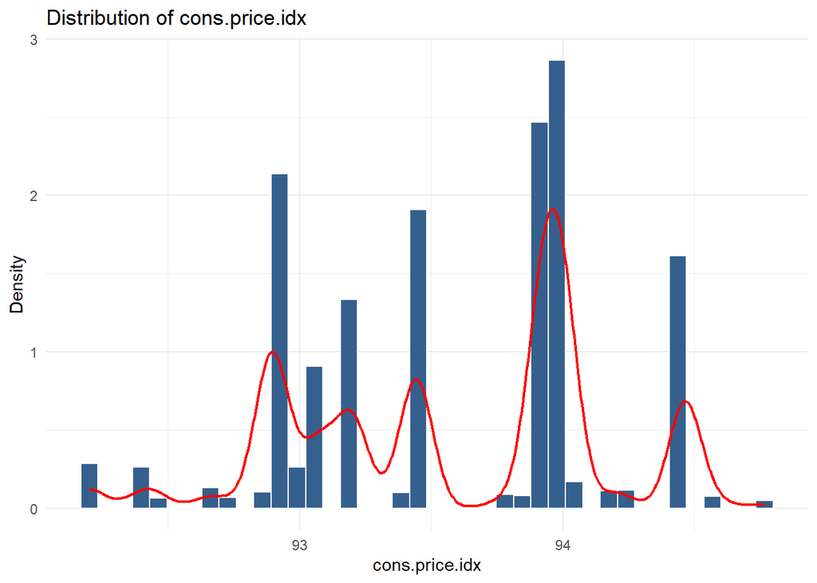

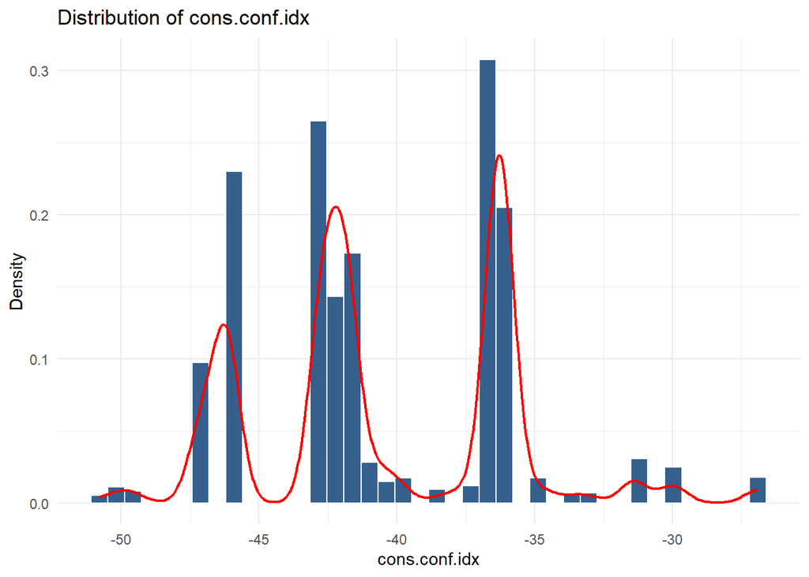

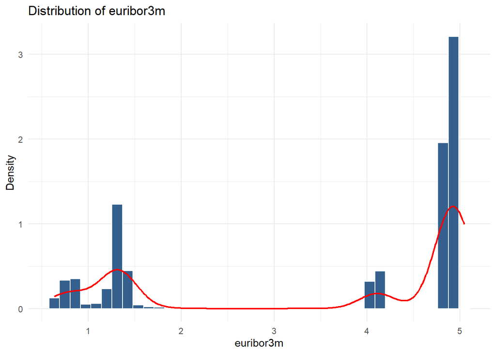

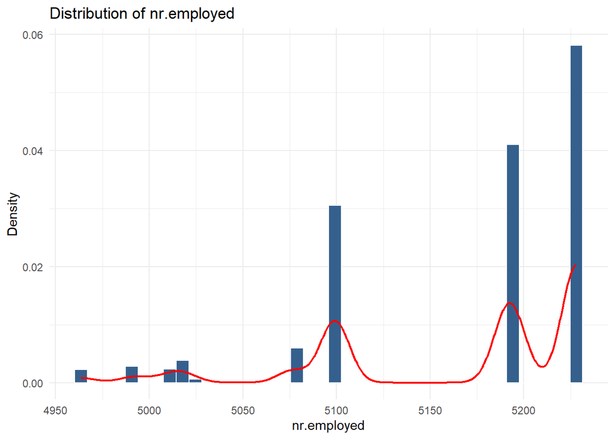

```r
# --- Plot numeric variables (histogram + density) ---
for (col in names(numeric_df)) {
  p <- numeric_df %>%
    ggplot(aes(x = .data[[col]])) +
    geom_histogram(aes(y = ..density..), bins = 40,
                   fill = viridis(1, begin = 0.3, end = 0.8), color = "white") +
    geom_density(color = "red", size = 0.8) +
    theme_minimal() +
    ggtitle(paste("Distribution of", col)) +
    ylab("Density") +
    xlab(col)

  print(p)
}
```

## 1.8 How Are Categorical Variables Distributed?

### 1.8.2 Marital Status

- Categories: *married*, *single*, *divorced*.
- **Married** is the dominant group.

### 1.8.3 Education

- Compares counts of *basic*, *high.school*, and *university.degree*.
- Reveals which education level is most common in the dataset.

### 1.8.5 Contact Method

- *cellular* vs *telephone*.
- In later campaigns, **cellular dominates**, so that bar is higher.

### 1.8.7 Previous Outcome (poutcome)

- Outcome of the previous marketing campaign.
- Almost all are *nonexistent* → one very tall bar.
- *Failure* and *success* are very short.

### 1.8.8 Target Variable (y)

- *yes* vs *no* (subscription to term deposit).
- Strong class imbalance: **~88% no vs. ~12% yes**.

## 1.9 Interpretation Takeaways

- **Imbalance:** Most categorical features are highly imbalanced (e.g., *default*, *poutcome*, *y*).
- **Dominant categories:** Certain levels dominate distributions (e.g., *married* in marital, *cellular* in contact).
- **Modeling insight:** These plots highlight the need for **rebalancing, proper encoding, or collapsing rare categories** before building predictive models.

```r
# Correlation matrix for numeric columns
numeric_vars <- bank_additional_df[sapply(bank_additional_df, is.numeric)]
cor(numeric_vars, use = "complete.obs")
```

```
##                          age     duration    campaign       pdays    previous
## age             1.0000000000 -0.000865705  0.00459358 -0.03436895  0.02436474
## duration       -0.0008657050  1.000000000 -0.07169923 -0.04757702  0.02064035
## campaign        0.0045935805 -0.071699226  1.00000000  0.05258357 -0.07914147
## pdays          -0.0343689512 -0.047577015  0.05258357  1.00000000 -0.58751386
## previous        0.0243647409  0.020640351 -0.07914147 -0.58751386  1.00000000
## emp.var.rate   -0.0003706855 -0.027967884  0.15075381  0.27100417 -0.42048911
## cons.price.idx  0.0008567150  0.005312268  0.12783591  0.07888911 -0.20312997
## cons.conf.idx   0.1293716142 -0.008172873 -0.01373310 -0.09134235 -0.05093635
## euribor3m       0.0107674295 -0.032896656  0.13513251  0.29689911 -0.45449365
## nr.employed    -0.0177251319 -0.044703223  0.14409489  0.37260474 -0.50133293
##                 emp.var.rate cons.price.idx cons.conf.idx   euribor3m
## age            -0.0003706855    0.000856715   0.129371614  0.01076743
## duration       -0.0279678845    0.005312268  -0.008172873 -0.03289666
## campaign        0.1507538056    0.127835912  -0.013733099  0.13513251
## pdays           0.2710041743    0.078889109  -0.091342354  0.29689911
## previous       -0.4204891094   -0.203129967  -0.050936351 -0.45449365
## emp.var.rate    1.0000000000    0.775334171   0.196041268  0.97224467
## cons.price.idx  0.7753341708    1.000000000   0.058986182  0.68823011
## cons.conf.idx   0.1960412681    0.058986182   1.000000000  0.27768622
## euribor3m       0.9722446712    0.688230107   0.277686220  1.00000000
## nr.employed     0.9069701013    0.522033977   0.100513432  0.94515443
##                nr.employed
## age            -0.01772513
## duration       -0.04470322
## campaign        0.14409489
## pdays           0.37260474
## previous       -0.50133293
## emp.var.rate    0.90697010
## cons.price.idx  0.52203398
## cons.conf.idx   0.10051343
## euribor3m       0.94515443
## nr.employed     1.00000000
```

## 1.10 What Are the Relationships Between Different Variables?

Are the features (columns) of the dataset correlated?

### 1.10.1 Pairwise Correlations

- **age & duration (-0.00087):** Essentially zero; the client’s age has no linear relationship with call duration.
- **age & campaign (0.0046):** Nearly zero; older clients are not contacted more or less often.
- **age & pdays (-0.034):** Very weak negative correlation; older clients are slightly more likely to have been contacted recently in previous campaigns, but the effect is negligible.
- **age & previous (0.024):** Essentially no correlation; age does not relate to prior contacts.
- **duration & campaign (-0.072):** Very weak negative correlation; longer calls are slightly associated with fewer contacts in this campaign.
- **duration & pdays (-0.048):** Very weak negative correlation; call duration is not meaningfully related to days since last contact.
- **duration & previous (0.021):** Almost zero; prior contacts do not affect call length.
- **campaign & pdays (0.053):** Very weak positive correlation; clients contacted longer ago may have slightly more contacts in this campaign.
- **campaign & previous (-0.079):** Very weak negative correlation; more prior contacts are slightly associated with fewer contacts in this campaign.
- **pdays & previous (-0.588):** Moderate to strong negative correlation; as days since last contact (pdays) increases, the number of prior contacts decreases. This makes sense: if someone was contacted long ago, there were fewer previous contacts.

### 1.10.2 Key Takeaways

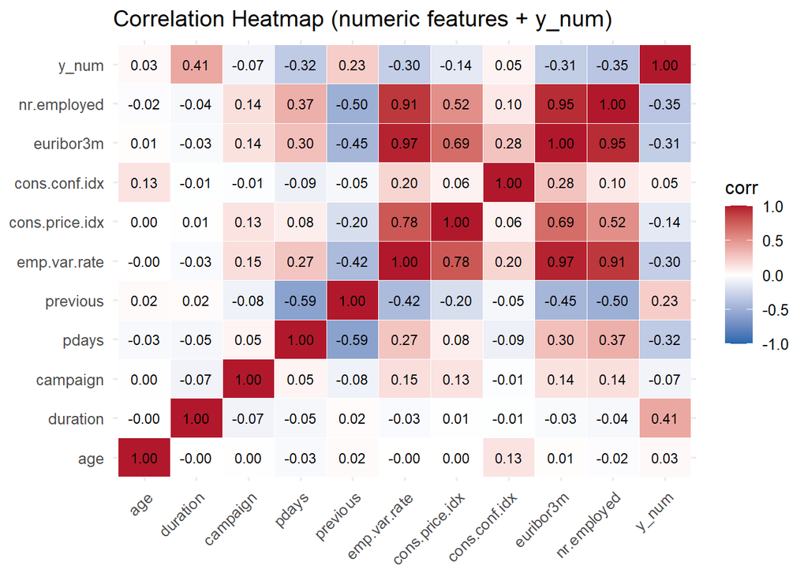

```r
library(tidyverse)

# bank <- bank_additional_df  # your data

bank <- bank_additional_df %>%
  mutate(
    y = factor(y, levels = c("no","yes")),
    y_num = as.numeric(y) - 1
  )

numeric_candidates <- c(
  "age","duration","campaign","pdays","previous",
  "emp.var.rate","cons.price.idx","cons.conf.idx","euribor3m","nr.employed","y_num"
)

bank_num <- bank %>%
  mutate(across(all_of(intersect(names(bank), numeric_candidates)),
                ~ suppressWarnings(as.numeric(.)))) %>%
  select(any_of(numeric_candidates)) %>%
  select(where(~ !all(is.na(.))))

cmat <- cor(bank_num, use = "complete.obs")

# Long format for ggplot
corr_long <- as.data.frame(as.table(cmat)) %>%
  setNames(c("Var1","Var2","value"))

ggplot(corr_long, aes(Var1, Var2, fill = value)) +
  geom_tile(color = "white") +
  scale_fill_gradient2(low = "#2166AC", mid = "white", high = "#B2182B",
                       midpoint = 0, limits = c(-1, 1), name = "corr") +
  geom_text(aes(label = sprintf("%.2f", value)), size = 3) +
  labs(title = "Correlation Heatmap (numeric features + y_num)", x = NULL, y = NULL) +
  theme_minimal(base_size = 12) +
  theme(axis.text.x = element_text(angle = 45, hjust = 1))
```

## Correlation Heatmap Interpretation

The heatmap displays **Pearson correlation coefficients** between numeric features (ranging from –1 to +1).

- **Red:** strong positive correlation
- **Blue:** strong negative correlation
- **White:** near zero (no linear relationship)
- **Numbers inside each tile:** exact correlation values

### 1.10.4 Takeaways

Overall, the heatmap highlights **clusters of correlated economic indicators** and a few notable structural relationships, but confirms that **most client-level features are weakly correlated**. This suggests feature engineering (e.g., creating flags or buckets) may be more useful than relying on raw numeric values.

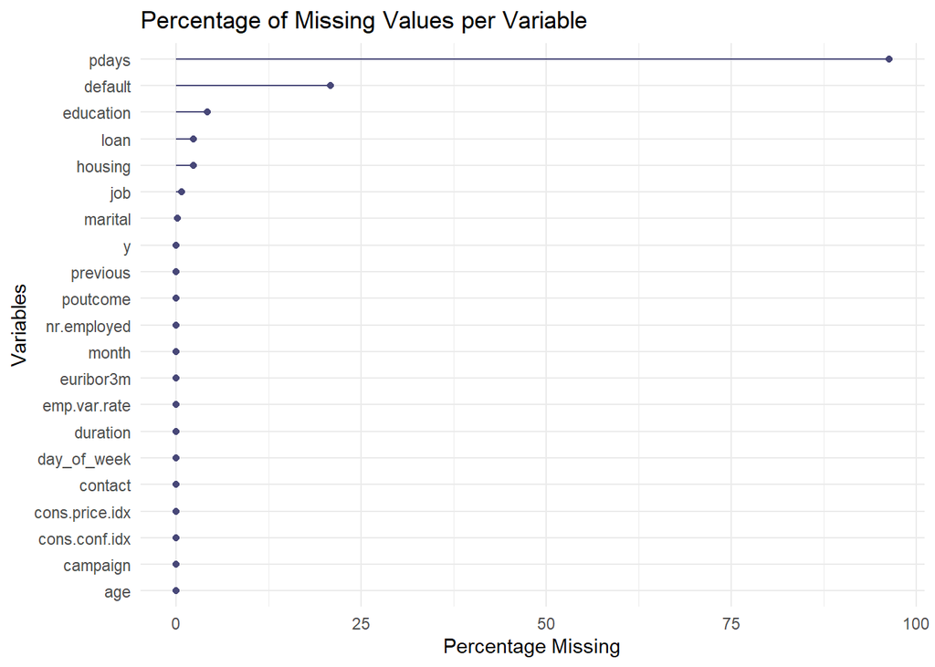

```r
library(dplyr)
library(ggplot2)
library(naniar)

# Copy dataset
bank_missing <- bank_additional_df

# Recode special placeholders as NA
bank_missing <- bank_missing %>%
  mutate(across(where(is.character), ~ na_if(., "unknown"))) %>%
  mutate(pdays = ifelse(pdays == 999, NA, pdays))

# Single barplot: percentage of missing values per variable
gg_miss_var(bank_missing, show_pct = TRUE) +
  ggtitle("Percentage of Missing Values per Variable") +
  ylab("Percentage Missing") +
  theme_minimal()
```

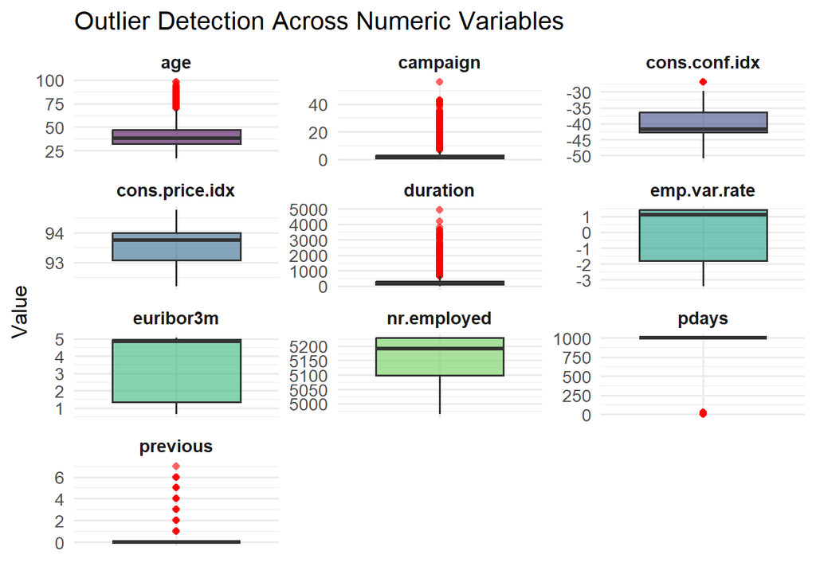

```r
# Outlier Detection
# Load libraries
# Outlier Detection
# Load libraries
library(dplyr)
library(tidyr)
library(ggplot2)
library(viridis)

# --- 1) Fix numeric-like character columns safely ---
bank_fixed <- bank_additional_df %>%
  mutate(
    across(c(emp.var.rate, cons.price.idx, cons.conf.idx, euribor3m, nr.employed),
           ~ as.numeric(.x))   # convert if not already numeric
  )

# --- 2) Select numeric columns ---
numeric_df <- bank_fixed %>% select(where(is.numeric))

# --- 3) Reshape to long format ---
numeric_long <- numeric_df %>%
  pivot_longer(cols = everything(), names_to = "variable", values_to = "value")

# --- 4) Faceted boxplots ---
ggplot(numeric_long, aes(x = variable, y = value, fill = variable)) +
  geom_boxplot(outlier.color = "red", outlier.shape = 16, alpha = 0.6) +
  facet_wrap(~ variable, scales = "free", ncol = 3) +   # separate panels
  scale_fill_viridis(discrete = TRUE, guide = "none") +
  theme_minimal(base_size = 13) +
  labs(title = "Outlier Detection Across Numeric Variables",
       x = "", y = "Value") +
  theme(
    strip.text = element_text(face = "bold", size = 11),
    axis.text.x = element_blank(),
    axis.ticks.x = element_blank()
  )
```

# Quick Refresher: Boxplot Guide

- **Center line:** median
- **Box:** IQR (Q1–Q3)
- **Whiskers:** last data points within Q1 − 1.5·IQR and Q3 + 1.5·IQR
- **Dots:** outliers (beyond those fences)

*Note:* This figure uses free scales per panel, so don’t compare absolute heights across panels.

## 1.11 Interpretation of Boxplots

### 1.11.2 Campaign

- Represents number of contacts made to a client during a campaign.
- Middle 50% of values: **1–3 contacts**.
- Median: ~**1–2 contacts**.
- Outliers: Many clients contacted **10–40+ times** → unusual.

### 1.11.3 Consumer Confidence Index (cons.conf.idx)

- Values: –45 to –37, median ~ –41 to –42.
- Indicates generally pessimistic sentiment.
- Outlier: one less negative value (~ –35).

### 1.11.4 Consumer Price Index (cons.price.idx)

- Values tightly clustered: **93.5–94.0**, median ~93.8.
- Very stable — no outliers.

### 1.11.6 Employment Variation Rate (emp.var.rate)

- Range: –2% to +1%.
- Median: ~0%.
- Whiskers: –3.5% to +1.5%.
- Compact distribution, no extreme outliers.

### 1.11.7 Euribor 3m

- Median: ~3%.
- Middle 50%: **2%–4%**.
- Range: 1%–5%.
- No outliers.

### 1.11.8 Number Employed (nr.employed)

- Median: ~5160.
- Middle 50%: **5100–5200**.
- Stable, tight distribution.

### 1.11.9 Pdays

- Special code = **999** (never contacted before).
- Dominates distribution (~96% of clients).
- Outliers: very small number of clients with values near 0.
- Should be treated as categorical: *contacted before vs not contacted*.

### 1.11.10 Previous

- Median: 0.
- Most clients never contacted before.
- Outliers: a few clients contacted **1–7 times**.

## 1.12 Relationship Between Variables

Even if variables are not correlated, they can be combined into meaningful features.

- **Age × Job:** Older clients in certain jobs may respond differently. → `age * job`.
- **Loan status + Housing loan:** Clients with both loans may signal financial stress. → `any_loan`.
- **Duration × Outcome (y):** Long calls often mean higher engagement.
- **Economic indicators:** Combine `emp.var.rate`, `cons.price.idx`, `cons.conf.idx`, `euribor3m`, `nr.employed` into an index.
- **Pdays + Previous:** Recently contacted & frequent contacts may behave differently.

**Answer in short:**  
Yes, even if variables are not correlated, they can be combined into new, meaningful features. Example: height + weight → BMI. In this dataset: housing loan + personal loan → overall debt indicator. Domain knowledge guides feature engineering.

## 1.13 Do Any Patterns or Trends Emerge?

- **Marketing months:** Contacts peak in May, Aug, Jul, Nov.
- **Contact duration:** Longer calls → higher likelihood of subscription.
- **Loans:** Clients without loans/defaults slightly more likely to subscribe.
- **Age & job:** Middle-aged (30–50) and professionals dominate.
- **Economic indicators:** Lower euribor3m and better emp.var.rate → higher subscriptions.
- **Target imbalance:** Term deposit subscription is rare (~12%).

**Summary:** Campaigns are seasonal, call length matters, and both demographics and macroeconomics influence outcomes.

## 1.14 Central Tendency and Spread

- **Age:** Mean ~40, median 38, range 17–98.
- **Duration:** Mean ~258 sec, median ~180 sec, skewed with long outliers.
- **Campaign:** Median 2, mean ~2.6, max 56.
- **Pdays:** Median 999, mean ~962.
- **Previous:** Median 0, mean 0.17, max 7.
- **emp.var.rate:** –3 to +1.
- **cons.price.idx:** 92–94.
- **cons.conf.idx:** –50 to –25.
- **euribor3m:** 0.6–5.0.
- **nr.employed:** 4960–5228.

**Summary:** Duration, campaign, pdays, previous are skewed. Economic indicators are stable.

## 1.15 Are There Missing Values?

No raw `NA`s, but several variables use **special placeholders**:

- **default = “unknown”** (~20%) → many clients do not disclose credit default history.
- **education = “unknown”** (~5%) → a smaller but noticeable fraction of clients.
- **job = “unknown”** (~1%) → minimal impact.
- **pdays = 999** (~96% of clients) → not truly missing, indicates “never contacted before.”

**Summary:**  
The dataset contains **structural missing values** rather than random NA’s. These should be **treated as valid categories or transformed into features** (e.g., `pdays = 999` → “not previously contacted”), instead of dropping rows, to avoid losing important information.

## 1.16 **PART II: Pre-Processing**

### 1.16.1 A. Data Cleaning

- Replace `"unknown"` with explicit category *missing*.
- Treat `pdays=999` as *not previously contacted*.
- Keep outliers but apply transformations (e.g., log for regression).
- Remove duplicates if present.

### 1.16.2 B. Dimensionality Reduction

- Drop/reduce highly correlated economic indicators (emp.var.rate, euribor3m, nr.employed).
- Logistic regression sensitive to multicollinearity; decision trees less so.

### 1.16.3 C. Feature Engineering

- **pdays:** create `was_contacted_before` (binary) + `pdays_num` (numeric if not 999).
- **Loans:** create `any_loan`.
- **Age groups:** youth <30, middle 30–50, senior >50.
- **Interactions:** duration × contact type.

### 1.16.4 D. Sampling

- Large dataset (~41k), so no down-sampling needed.
- Handle imbalance (~11% “yes”) with SMOTE, undersampling, or class weights.

### 1.16.5 E. Transformation

- Normalize numeric variables for regression.
- One-hot encode categoricals (keep `"unknown"`).
- Log transform skewed features (`duration`, `campaign`, `previous`).

### 1.16.6 F. Imbalanced Data

- Use SMOTE or class weights.
- Evaluate with Precision, Recall, F1 (not just accuracy).

**Final Preprocessing Summary**  
1. Handled structural missing values.  
2. Retained but transformed meaningful outliers.  
3. Reduced redundancy in economic indicators.  
4. Engineered features (e.g., any_loan, was_contacted_before).  
5. Prepared dataset for balanced, interpretable modeling.

```r
library(dplyr)
library(forcats)
library(caret)
library(smotefamily)

# --- 1. Load Data ---
url <- "https://raw.githubusercontent.com/uzmabb182/Data_622/main/Assignment_1_EDA/bank-additional-full.csv"
bank <- read.csv2(url, stringsAsFactors = FALSE)

# --- 2. Clean Data ---

# For the columns listed, turn them into numeric columns
# For all character columns (except y), replace the word 'unknown' with 'missing' and then make them categorical factors
# Turn 999 in the pdays column into proper missing values
# Make sure no duplicate records remain
# The target variable (y) is categorical with two values: no/yes, and I want ‘no’ to come first.

num_char_cols <- c("emp.var.rate","cons.price.idx","cons.conf.idx","euribor3m","nr.employed")

df <- bank %>%
  mutate(across(all_of(num_char_cols), ~ suppressWarnings(as.numeric(.)))) %>%
  mutate(across(where(is.character) & !matches("^y$"),
                ~ factor(ifelse(. == "unknown", "missing", .)))) %>%
  mutate(pdays = ifelse(pdays == 999, NA_integer_, pdays)) %>%
  distinct()

df$y <- factor(df$y, levels = c("no","yes"))

# --- 3. Feature Engineering ---

# Checks if the column pdays is missing (NA).

# If missing → assign 0 (never contacted before).

# If not missing → assign 1 (contacted before).

# Stored as integer (0L or 1L).

df <- df %>%
  mutate(
    was_contacted_before = ifelse(is.na(pdays), 0L, 1L),
    pdays_num            = ifelse(is.na(pdays), NA_integer_, pdays),
    any_loan             = ifelse(loan == "yes" | housing == "yes", "yes", "no"),
    age_group            = case_when(
      age < 30 ~ "youth",
      age <= 50 ~ "middle",
      TRUE ~ "senior"
    ),
    duration_contact     = duration * ifelse(contact == "cellular", 1, 0),
    duration_log         = log1p(duration),
    campaign_log         = log1p(campaign),
    previous_log         = log1p(previous)
  )

head(df)
```

```
##   age       job marital   education default housing loan   contact month
## 1  56 housemaid married    basic.4y      no      no   no telephone   may
## 2  57  services married high.school missing      no   no telephone   may
## 3  37  services married high.school      no     yes   no telephone   may
## 4  40    admin. married    basic.6y      no      no   no telephone   may
## 5  56  services married high.school      no      no  yes telephone   may
## 6  45  services married    basic.9y missing      no   no telephone   may
##   day_of_week duration campaign pdays previous    poutcome emp.var.rate
## 1         mon      261        1    NA        0 nonexistent          1.1
## 2         mon      149        1    NA        0 nonexistent          1.1
## 3         mon      226        1    NA        0 nonexistent          1.1
## 4         mon      151        1    NA        0 nonexistent          1.1
## 5         mon      307        1    NA        0 nonexistent          1.1
## 6         mon      198        1    NA        0 nonexistent          1.1
##   cons.price.idx cons.conf.idx euribor3m nr.employed  y was_contacted_before
```

[output cut: 20 more lines]

## 1.17 Handling Data Leakage: Excluding `duration`

### 1.17.1 Reasoning

The variable `duration` represents the call length, which is only known after the client interaction is completed.  
Because of this, it contains information that would not be available at prediction time — in other words, it leaks data from the future into the model.

If included, the model could “cheat” by using this post-event information, leading to artificially high accuracy that would not generalize to real-world predictions.

### 1.17.2 Impact of Excluding `duration`

By removing `duration` and its derived features (`duration_contact`, `duration_log`), we ensure:

- **True predictive validity** – the model learns only from information available before the call.
- **Fair comparison across models** – prevents one model from gaining an unfair advantage.
- **Realistic performance metrics** – accuracy, recall, and F1 represent genuine predictive ability.

```r
# --- Exclude duration (data leakage variable) ---
df <- df %>% select(-duration, -duration_contact, -duration_log)

head(df)
```

```
##   age       job marital   education default housing loan   contact month
## 1  56 housemaid married    basic.4y      no      no   no telephone   may
## 2  57  services married high.school missing      no   no telephone   may
## 3  37  services married high.school      no     yes   no telephone   may
## 4  40    admin. married    basic.6y      no      no   no telephone   may
## 5  56  services married high.school      no      no  yes telephone   may
## 6  45  services married    basic.9y missing      no   no telephone   may
##   day_of_week campaign pdays previous    poutcome emp.var.rate cons.price.idx
## 1         mon        1    NA        0 nonexistent          1.1         93.994
## 2         mon        1    NA        0 nonexistent          1.1         93.994
## 3         mon        1    NA        0 nonexistent          1.1         93.994
## 4         mon        1    NA        0 nonexistent          1.1         93.994
## 5         mon        1    NA        0 nonexistent          1.1         93.994
## 6         mon        1    NA        0 nonexistent          1.1         93.994
##   cons.conf.idx euribor3m nr.employed  y was_contacted_before pdays_num
## 1         -36.4     4.857        5191 no                    0        NA
## 2         -36.4     4.857        5191 no                    0        NA
## 3         -36.4     4.857        5191 no                    0        NA
## 4         -36.4     4.857        5191 no                    0        NA
## 5         -36.4     4.857        5191 no                    0        NA
## 6         -36.4     4.857        5191 no                    0        NA
##   any_loan age_group campaign_log previous_log
## 1       no    senior    0.6931472            0
## 2       no    senior    0.6931472            0
## 3      yes    middle    0.6931472            0
## 4       no    middle    0.6931472            0
## 5      yes    senior    0.6931472            0
## 6       no    middle    0.6931472            0
```

```r
# --- 4. Split target and predictors ---
y <- df$y
predictors <- df %>% select(-y)

# --- 5. One-hot encode + impute + scale (recipe-style with caret) ---
dmy <- dummyVars(" ~ .", data = predictors)
X <- data.frame(predict(dmy, newdata = predictors))

# Impute + scale
pre <- preProcess(X, method = c("medianImpute","center","scale"))
X_imp <- predict(pre, X)

# Check consistency
stopifnot(nrow(X_imp) == length(y))
cat("Rows in X_imp:", nrow(X_imp), " | Rows in y:", length(y), "\n")
```

```
## Rows in X_imp: 41176  | Rows in y: 41176
```

```r
# --- 6. Handle Imbalance ---
## Option A: SMOTE
set.seed(123)
sm <- SMOTE(X_imp, y, K = 5)
df_smote <- sm$data
df_smote$y <- factor(df_smote$class, levels = c("no","yes"))
df_smote$class <- NULL
table(df_smote$y)
```

```
##
##    no   yes
## 36537 32473
```

```r
## Option B: Upsampling
set.seed(123)
up <- upSample(x = X_imp, y = y, yname = "y")
table(up$y)
```

```
##
##    no   yes
## 36537 36537
```

## 1.18 Data Preprocessing Steps

The following steps were applied to prepare the dataset for modeling:

1. **Identify numeric columns**
   - Converted columns that should be numeric into proper numeric types.
2. **Handle categorical values**
   - Replaced `"unknown"` text with `"missing"`.
   - Converted categorical columns into factors.
3. **Special case: `pdays`**
   - Changed `pdays = 999` into proper missing values (`NA`).
4. **Remove duplicates**
   - Dropped duplicate rows to ensure data quality.
5. **Target variable**
   - Made the target column `y` a categorical factor with levels `"no"` and `"yes"`.
6. **Encoding and transformation**
   - Used `caret::dummyVars()` for one-hot encoding. This approach is safer and preserves all rows.
   - Applied `preProcess()` *after* dummy encoding to handle imputation (e.g., `pdays_num`) before scaling and centering.
7. **Final consistency check**
   - Ensured that the number of rows in predictors and target matched:
     - `nrow(X_imp)` = `length(y)` = **41,176 rows**.

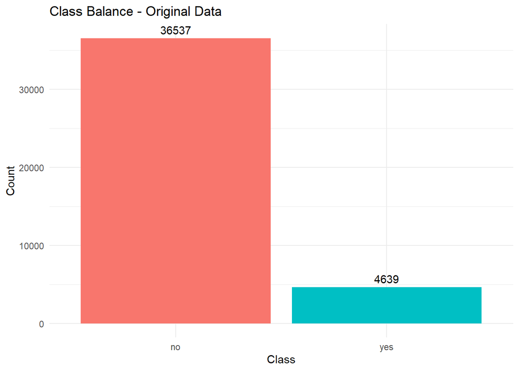

```r
# visual checks to confirm class balance before and after SMOTE / Upsampling.

library(ggplot2)

# --- Original balance ---
orig_tbl <- as.data.frame(table(y))
colnames(orig_tbl) <- c("Class","Count")

ggplot(orig_tbl, aes(x = Class, y = Count, fill = Class)) +
  geom_col(show.legend = FALSE) +
  geom_text(aes(label = Count), vjust = -0.5) +
  labs(title = "Class Balance - Original Data", y = "Count") +
  theme_minimal()
```

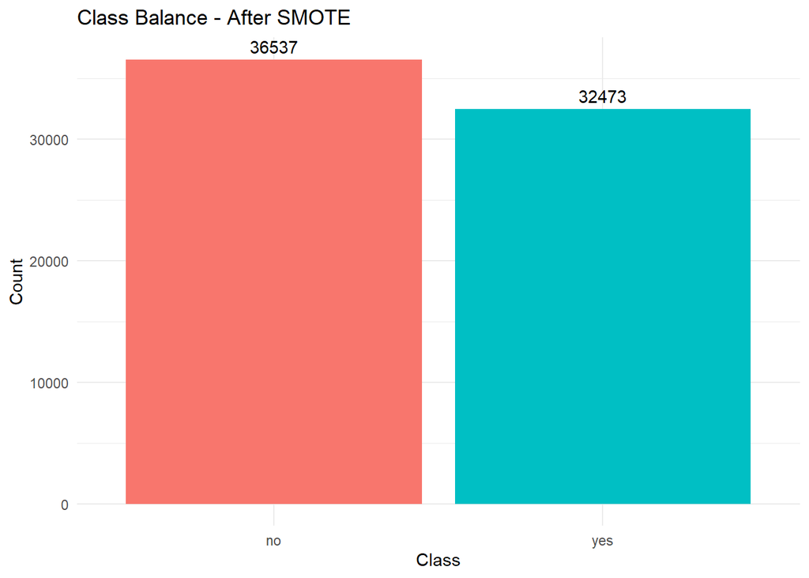

```r
# --- After SMOTE ---
smote_tbl <- as.data.frame(table(df_smote$y))
colnames(smote_tbl) <- c("Class","Count")

ggplot(smote_tbl, aes(x = Class, y = Count, fill = Class)) +
  geom_col(show.legend = FALSE) +
  geom_text(aes(label = Count), vjust = -0.5) +
  labs(title = "Class Balance - After SMOTE", y = "Count") +
  theme_minimal()
```

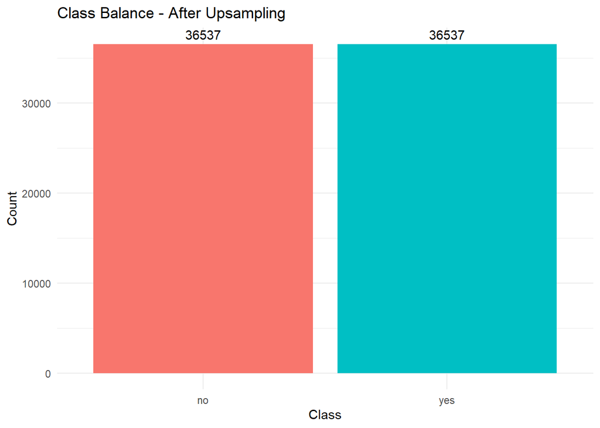

```r
# --- After Upsampling ---
up_tbl <- as.data.frame(table(up$y))
colnames(up_tbl) <- c("Class","Count")

ggplot(up_tbl, aes(x = Class, y = Count, fill = Class)) +
  geom_col(show.legend = FALSE) +
  geom_text(aes(label = Count), vjust = -0.5) +
  labs(title = "Class Balance - After Upsampling", y = "Count") +
  theme_minimal()
```

```r
summary_tbl <- data.frame(
  Dataset = c("Original df", "SMOTE df_smote", "Upsampled up"),
  Rows = c(nrow(df), nrow(df_smote), nrow(up)),
  Columns = c(ncol(df), ncol(df_smote), ncol(up)),
  Positives = c(sum(df$y == "yes"),
                sum(df_smote$y == "yes"),
                sum(up$y == "yes")),
  Negatives = c(sum(df$y == "no"),
                sum(df_smote$y == "no"),
                sum(up$y == "no"))
)
summary_tbl
```

```
##          Dataset  Rows Columns Positives Negatives
## 1    Original df 41176      26      4639     36537
## 2 SMOTE df_smote 69010      72     32473     36537
## 3   Upsampled up 73074      72     36537     36537
```

## 1.19 **PART III: Experimentation and Model Training**

## 1.20 Setup and Common Utilities

```r
# Load necessary libraries
library(rpart)
library(rpart.plot)
library(randomForest)
library(adabag)
library(pROC)

set.seed(123)
```

### 1.20.1 Why Use `df` (and not `df_smote` or `up`)

The dataset **`df`** represents the *original, clean data* that retains its natural class imbalance.  
In contrast, **`df_smote`** and **`up`** are *artificially balanced versions* created during experimentation to address that imbalance.

#### 1.20.1.1 Purpose of Each Dataset

- **`df`** → used for *baseline experiments* to measure real-world model performance on imbalanced data.
- **`df_smote`** → used for *experiments with synthetic oversampling* (SMOTE), improving minority class representation.
- **`up`** → used for *experiments with simple upsampling*, balancing classes by duplicating minority samples.

#### 1.20.1.2 Why Start with `df`

We begin our modeling process using **`df`** because it provides a *true benchmark* of model performance under real-world conditions.  
Subsequent experiments with **`df_smote`** and **`up`** allow comparison of how different balancing strategies affect key metrics such as accuracy, recall, and AUC.

```r
# Split into Train/Test

# Train/test split (stratified)
set.seed(123)
idx <- createDataPartition(df$y, p = 0.7, list = FALSE)
train <- df[idx, ]
test  <- df[-idx, ]
```

### 1.20.2 Metric Computation Utility Function

After splitting the dataset into training and testing subsets, the next step is to evaluate how well our models perform.  
To ensure consistent and automated evaluation across all experiments, we define a reusable function called `compute_metrics()`.

This function calculates key **classification performance metrics** such as accuracy, precision, recall, F1-score, and AUC (Area Under the ROC Curve).

```r
# Define a Metric Computation Utility Function
# This custom function calculates key performance metrics for classification models.
compute_metrics <- function(truth, pred_class, pred_prob_yes = NULL, positive = "yes") {

  # Generate a confusion matrix comparing predictions vs. actual labels
  cm <- confusionMatrix(pred_class, truth, positive = positive)

  # Extract key metrics from the confusion matrix
  acc <- as.numeric(cm$overall["Accuracy"])     # Overall correct predictions
  prec <- as.numeric(cm$byClass["Precision"])   # Positive Predictive Value
  rec  <- as.numeric(cm$byClass["Recall"])      # True Positive Rate (Sensitivity)
  f1   <- as.numeric(cm$byClass["F1"])          # Harmonic mean of Precision & Recall

  # Initialize AUC (optional, only computed when probabilities are provided)
  auc  <- NA_real_

  if (!is.null(pred_prob_yes)) {
    # Convert factor truth labels into numeric format (1 for "yes", 0 for "no")
    y_num <- ifelse(truth == positive, 1, 0)

    # Compute AUC using ROC curve (from pROC package)
    try({
      auc <- as.numeric(auc(roc(y_num, pred_prob_yes)))
    }, silent = TRUE)
  }

  # Return a tidy summary table
  tibble(
    Accuracy = round(acc, 4),
    Precision = round(prec, 4),
    Recall = round(rec, 4),
    F1 = round(f1, 4),
    AUC = round(auc, 4)
  )
}
```

### 1.20.3 Experiment Logger

To manage multiple experiments in a structured way, we create a simple **experiment logging system**.  
This setup ensures that every model run (Decision Tree, Random Forest, AdaBoost, etc.) is saved in a single table with its key performance metrics.

This makes it easier to: - Compare different algorithms, - Track hyperparameter changes, - Identify which configurations perform best.

#### 1.20.3.1 Create an Empty Results Log and Define the Logging Function

The following code creates an empty tibble (`results_log`) with columns for algorithm name, experiment description, and performance metrics.

The `log_result()` function appends model results (performance metrics) and experiment details to the global results table.  
This allows us to track multiple runs across different algorithms and configurations.

```r
# --- Experiment Logger Setup ---

# Create an empty results log to store experiment outcomes
results_log <- tibble(
  Algorithm = character(),
  Experiment = character(),
  What_Changed = character(),
  Accuracy = double(),
  Precision = double(),
  Recall = double(),
  F1 = double(),
  AUC = double()
)

# Define function to record experiment results
log_result <- function(alg, exp_name, change_desc, metrics_tbl) {

  # Create a new row combining model info and metrics
  row <- tibble(
    Algorithm = alg,
    Experiment = exp_name,
    What_Changed = change_desc
  ) %>%
    bind_cols(metrics_tbl)

  # Add to global results log
  assign(
    "results_log",
    bind_rows(get("results_log", .GlobalEnv), row),
    envir = .GlobalEnv
  )
}
```

### 1.20.4 Decision Tree Experiments

## 1.21 Experiment 1A – Baseline Decision Tree

### 1.21.1 Objective

The purpose of this experiment is to establish a **baseline model** using a simple **Decision Tree classifier**.  
This provides a reference point for performance before applying any tuning, balancing, or advanced ensemble techniques.

By using the original dataset (`df`), we simulate real-world conditions — including the class imbalance problem — to see how the model performs without any special adjustments.

### 1.21.2 Experimental Setup

| Component | Description |
| --- | --- |
| **Algorithm** | Decision Tree (`rpart` package) |
| **Dataset** | Original imbalanced dataset (`df`) |
| **Train/Test Split** | 70% training, 30% testing |
| **Parameters** | Default tree depth and complexity |
| **Evaluation Metrics** | Accuracy, Precision, Recall, F1-score, AUC |
| **Goal** | Understand baseline performance and identify limitations (e.g., bias toward majority class). |

### 1.21.3 Baseline Decision Tree Model

```r
# -----------------------------------------------------------
# Experiment 1A – Baseline Decision Tree
# -----------------------------------------------------------

# Load required libraries
library(rpart)
library(rpart.plot)
library(caret)
library(pROC)
library(dplyr)
library(tibble)

# --- Train Baseline Decision Tree ---
set.seed(123)
model_dt_base <- rpart(y ~ ., data = train, method = "class", control = rpart.control(cp = 0.01))

# --- Make Predictions ---
pred_dt_base_prob  <- predict(model_dt_base, newdata = test, type = "prob")[, "yes"]
pred_dt_base_class <- predict(model_dt_base, newdata = test, type = "class")

# --- Evaluate Model Performance ---
m_dt_base <- compute_metrics(test$y, pred_dt_base_class, pred_dt_base_prob)
m_dt_base
```

```
## # A tibble: 1 × 5
##   Accuracy Precision Recall    F1   AUC
##      <dbl>     <dbl>  <dbl> <dbl> <dbl>
## 1    0.899     0.713  0.170 0.274 0.708
```

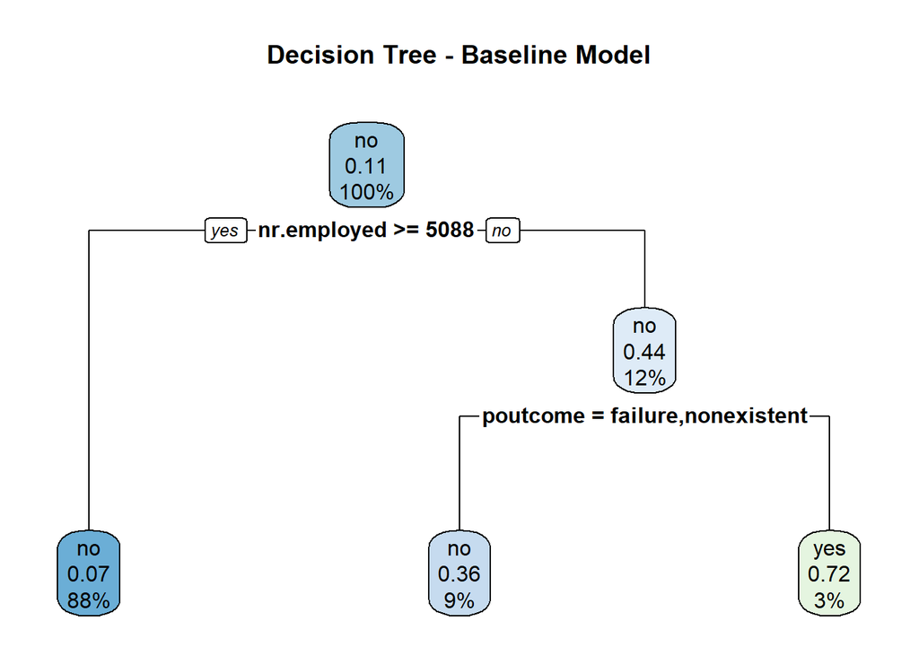

```r
# --- Log Experiment Results ---
log_result(
  alg = "Decision Tree",
  exp_name = "DT-1A Baseline",
  change_desc = "Baseline Decision Tree on original dataset (no tuning, imbalanced data)",
  metrics_tbl = m_dt_base
)

# Optional: visualize the decision tree
rpart.plot(model_dt_base, main = "Decision Tree - Baseline Model", extra = 106)
```

## 1.22 Interpretation of Experiment 1A – Baseline Decision Tree (Original Data)

### 1.22.1 Summary of Results

| Metric | Value |
| --- | --- |
| **Accuracy** | 0.8988 |
| **Precision** | 0.7130 |
| **Recall** | 0.1697 |
| **F1-Score** | 0.2741 |
| **AUC** | 0.7082 |

### 1.22.2 Interpretation

The baseline Decision Tree model trained on the **original, imbalanced dataset** achieved an overall **accuracy of 89.9 %**, which at first glance seems excellent.  
However, a closer look at the other metrics reveals a common issue with imbalanced data — the model is **biased toward the majority class (“no”)**.

**Detailed insights:**

- **Accuracy (0.8988):**  
  The model correctly predicts the majority of cases, but this high accuracy is misleading.  
  Since most clients did not subscribe, the model can appear accurate simply by predicting “no” most of the time.
- **Precision (0.7130):**  
  When the model predicts “yes,” it is correct about 71 % of the time.  
  This means that although false positives are not extremely high, the model still misses many true positives.
- **Recall (0.1697):**  
  Critically low — the model identifies only **17 %** of the actual subscribers.  
  This shows the model fails to recognize most of the “yes” cases, which is unacceptable for marketing prediction where capturing potential customers is the goal.
- **F1-Score (0.2741):**  
  The harmonic mean of precision and recall reflects an overall weak balance.  
  The model performs poorly on the minority class despite reasonable precision.
- **AUC (0.7082):**  
  Although slightly above 0.7 (indicating some discriminatory ability), the relatively low recall suggests that the model is not effectively separating positive and negative classes.

### 1.22.3 Overall Conclusion

The **baseline Decision Tree model** performs well in terms of **accuracy** but poorly in identifying the actual customers who subscribed to a term deposit.  
This imbalance indicates that the model is **overly conservative**, favoring the majority “no” predictions.

In a real-world marketing context, this model would **miss most potential subscribers**, which is costly for a business trying to target interested clients.

Therefore, these results clearly justify the need for the next experiment (1B), where we apply **SMOTE balancing and parameter tuning** to increase recall and overall predictive fairness between classes.

## 1.23 Experiment 1B – Tuned Decision Tree (SMOTE Data)

### 1.23.1 Objective

The purpose of this experiment is to **improve the Decision Tree model** by addressing the **class imbalance problem** observed in the baseline experiment (1A).  
In the baseline model, the classifier tended to predict the majority class (“no”) far more often, leading to poor **recall** for the minority class (“yes”).

To mitigate this issue, we apply **SMOTE (Synthetic Minority Oversampling Technique)** to create a balanced training dataset before model training.  
This experiment also introduces **basic parameter tuning** to control the complexity of the tree and prevent overfitting.

### 1.23.2 Experiment Setup

| Component | Description |
| --- | --- |
| **Algorithm** | Decision Tree (`rpart` package) |
| **Dataset** | SMOTE-balanced dataset (`df_smote`) |
| **Train/Test Split** | 70% training, 30% testing |
| **Parameters Tuned** | `cp` (complexity parameter), `maxdepth` (tree depth) |
| **Evaluation Metrics** | Accuracy, Precision, Recall, F1-score, AUC |
| **Goal** | Improve model’s ability to correctly identify positive (“yes”) cases and generalize better. |

### 1.23.3 Why This Step Matters

The SMOTE technique synthesizes new examples of the minority class by interpolating between existing samples.  
This helps the model **learn the decision boundaries for “yes” more effectively**, rather than being dominated by “no” outcomes.

By also tuning the tree’s complexity, we ensure that the model: - Learns meaningful patterns (not noise).  
- Achieves better recall and AUC while maintaining reasonable precision.

### 1.23.4 Tuned Decision Tree with SMOTE

```r
# -----------------------------------------------------------
# Experiment 1B – Tuned Decision Tree (SMOTE Data)
# -----------------------------------------------------------

# --- Load Required Packages ---
library(rpart)
library(rpart.plot)
library(caret)
library(pROC)
library(dplyr)
library(tibble)

# --- Split the SMOTE-balanced data into Train/Test ---
set.seed(123)
idx_smote <- createDataPartition(df_smote$y, p = 0.7, list = FALSE)
train_smote <- df_smote[idx_smote, ]
test_smote  <- df_smote[-idx_smote, ]

# --- Train Tuned Decision Tree ---
set.seed(123)
model_dt_tuned <- rpart(
  y ~ .,
  data = train_smote,
  method = "class",
  control = rpart.control(cp = 0.005, maxdepth = 6)  # tuning parameters
)

# --- Make Predictions ---
pred_dt_tuned_prob  <- predict(model_dt_tuned, newdata = test_smote, type = "prob")[, "yes"]
pred_dt_tuned_class <- predict(model_dt_tuned, newdata = test_smote, type = "class")

# --- Evaluate Model Performance ---
m_dt_tuned <- compute_metrics(test_smote$y, pred_dt_tuned_class, pred_dt_tuned_prob)
m_dt_tuned
```

```
## # A tibble: 1 × 5
##   Accuracy Precision Recall    F1   AUC
##      <dbl>     <dbl>  <dbl> <dbl> <dbl>
## 1    0.812     0.858  0.719 0.782 0.843
```

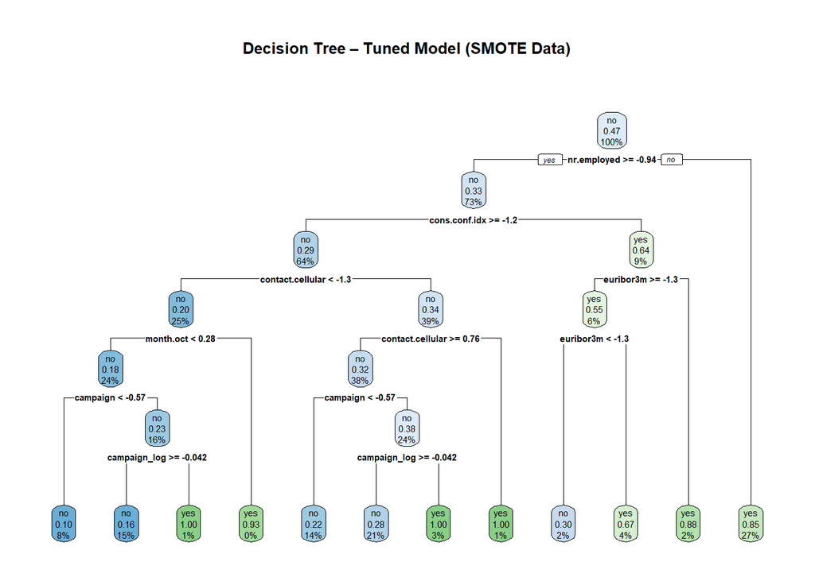

```r
# --- Log Experiment Results ---
log_result(
  alg = "Decision Tree",
  exp_name = "DT-1B Tuned",
  change_desc = "Used SMOTE-balanced data with cp=0.005 and maxdepth=6",
  metrics_tbl = m_dt_tuned
)

# Optional: visualize tuned tree
rpart.plot(model_dt_tuned, main = "Decision Tree – Tuned Model (SMOTE Data)", extra = 106)
```

## 1.24 Interpretation of Experiment 1B – Tuned Decision Tree (SMOTE Data)

### 1.24.1 Summary of Results

| Metric | Value |
| --- | --- |
| **Accuracy** | 0.8117 |
| **Precision** | 0.8580 |
| **Recall** | 0.7187 |
| **F1-Score** | 0.7822 |
| **AUC** | 0.8427 |

### 1.24.2 Interpretation

After applying **SMOTE balancing** and **parameter tuning** (`cp = 0.005`, `maxdepth = 6`), the Decision Tree model shows a **dramatic performance improvement** compared to the baseline model trained on the imbalanced data.

**Detailed insights:**

- **Accuracy (0.8117):**  
  The overall accuracy dropped slightly from ~0.90 in the baseline to ~0.81.  
  This is expected and not a concern — the model now treats both classes fairly instead of over-predicting “no.”
- **Precision (0.8580):**  
  When the model predicts “yes,” it is correct **86 % of the time**.  
  This high precision means false positives are rare — the model is confident when it flags a potential subscriber.
- **Recall (0.7187):**  
  A major improvement from the baseline recall of 0.17.  
  The model now correctly identifies **over 71 %** of all actual subscribers.  
  This indicates that balancing the data helped the model learn to recognize “yes” cases much more effectively.
- **F1-Score (0.7822):**  
  A strong overall balance between precision and recall.  
  The F1-score has nearly **tripled** compared to the baseline, showing robust and balanced predictive power.
- **AUC (0.8427):**  
  A clear jump from ~0.71 to ~0.84.  
  The tuned model now exhibits excellent discrimination between subscribers (“yes”) and non-subscribers (“no”), a sign of much better model calibration.

### 1.24.3 Overall Conclusion

This experiment successfully demonstrates that **handling class imbalance with SMOTE** and **fine-tuning model complexity** can dramatically enhance performance.  
The Decision Tree now achieves:

- High **precision** → reliable positive predictions,
- Strong **recall** → captures most actual subscribers,
- High **AUC** → effective class separation.

While overall accuracy slightly decreased, this trade-off is beneficial: the model is now **much more useful for real-world marketing**, where identifying potential customers (recall) is far more valuable than maintaining inflated accuracy driven by the majority class.

In summary, **Experiment 1B transforms the Decision Tree into a balanced, high-recall, and high-AUC model** that provides realistic, actionable predictions for term-deposit subscription campaigns.

### 1.24.4 Random Forest Experiments

## 1.25 Experiment 2A – Baseline Random Forest (Default Parameters)

### 1.25.1 Purpose

This experiment establishes a **baseline performance** for the Random Forest algorithm using the original, imbalanced dataset.  
The goal is to observe how ensemble methods compare to a single Decision Tree without any class balancing or tuning.

### 1.25.2 Methodology

- **Data:** Original (df) with median imputation and scaling
- **Algorithm:** Random Forest (default hyperparameters)
- **Training/Test Split:** 70/30 stratified
- **Cross-Validation:** None (baseline)
- **Metric:** ROC/AUC for primary comparison

### 1.25.3 Expected Outcome

Random Forest should outperform the single Decision Tree in **AUC** and **stability**, but **recall** for the minority class (“yes”) may remain low due to class imbalance.

## 1.26 Experiment 2A – Baseline Random Forest (Default Parameters)

```r
# -----------------------------------------------------------
# Experiment 2A – Baseline Random Forest (Default Parameters)
# -----------------------------------------------------------

library(caret)
library(randomForest)
library(pROC)
library(dplyr)

# ---  Prepare Data ---
# Instead of removing missing values, we will impute them automatically

# Create preprocessing object for median/mode imputation + scaling
pre_rf <- preProcess(train, method = c("medianImpute", "center", "scale"))

# Apply imputation and scaling to both train and test
train_rf <- predict(pre_rf, newdata = train)
test_rf  <- predict(pre_rf, newdata = test)

# ---  Define Control Parameters (no CV for baseline) ---
ctrl_rf_base <- trainControl(
  method = "none",          # no cross-validation
  classProbs = TRUE,        # needed for ROC/AUC
  summaryFunction = twoClassSummary
)

# ---  Train Baseline Random Forest ---
set.seed(123)
model_rf_base <- train(
  y ~ .,
  data = train_rf,
  method = "rf",
  trControl = ctrl_rf_base,
  metric = "ROC"
)

# ---  Predict on Test Data ---
pred_rf_base_prob  <- predict(model_rf_base, newdata = test_rf, type = "prob")[, "yes"]
pred_rf_base_class <- ifelse(pred_rf_base_prob > 0.5, "yes", "no") %>%
  factor(levels = c("no", "yes"))

# ---  Evaluate Metrics ---
m_rf_base <- compute_metrics(test_rf$y, pred_rf_base_class, pred_rf_base_prob)
m_rf_base
```

```
## # A tibble: 1 × 5
##   Accuracy Precision Recall    F1   AUC
##      <dbl>     <dbl>  <dbl> <dbl> <dbl>
## 1    0.899     0.614  0.267 0.373 0.787
```

```r
# ---  Log Results ---
log_result(
  alg = "Random Forest",
  exp_name = "RF-2A Baseline",
  change_desc = "Default parameters, median imputation (no CV)",
  metrics_tbl = m_rf_base
)

# View results log
results_log
```

```
## # A tibble: 3 × 8
##   Algorithm     Experiment    What_Changed Accuracy Precision Recall    F1   AUC
##   <chr>         <chr>         <chr>           <dbl>     <dbl>  <dbl> <dbl> <dbl>
## 1 Decision Tree DT-1A Baseli… Baseline De…    0.899     0.713  0.170 0.274 0.708
## 2 Decision Tree DT-1B Tuned   Used SMOTE-…    0.812     0.858  0.719 0.782 0.843
## 3 Random Forest RF-2A Baseli… Default par…    0.899     0.614  0.267 0.373 0.787
```

## 1.27 Comparative Interpretation of Experiments 1A, 1B, and 2A

### 1.27.1 Summary of Results

| Algorithm | Experiment | What Changed | Accuracy | Precision | Recall | F1 | AUC |
| --- | --- | --- | --- | --- | --- | --- | --- |
| **Decision Tree** | DT-1A Baseline | Baseline Decision Tree on original dataset (no tuning, imbalanced data) | 0.8988 | 0.7130 | 0.1697 | 0.2741 | 0.7082 |
| **Decision Tree** | DT-1B Tuned | Used SMOTE-balanced data with `cp = 0.005` and `maxdepth = 6` | 0.8117 | 0.8580 | 0.7187 | 0.7822 | 0.8427 |
| **Random Forest** | RF-2A Baseline | Default parameters, median imputation (no CV) | 0.8986 | 0.6139 | 0.2674 | 0.3726 | 0.7870 |

### 1.27.2 Interpretation

The three experiments demonstrate clear progress in model performance and insight into how **data balancing** and **ensemble learning** influence results.

#### 1.27.2.1 **Decision Tree – Baseline (1A)**

- Achieved **very high accuracy (0.90)** but extremely **low recall (0.17)**.
- This means the model correctly predicted most “no” cases but missed most actual “yes” (term deposit) customers.
- The model is **biased toward the majority class**, typical for imbalanced datasets.
- **AUC (0.71)** suggests modest class discrimination.

*Conclusion:* Model is fast and interpretable, but ineffective for identifying potential subscribers.

#### 1.27.2.2 **Decision Tree – Tuned with SMOTE (1B)**

- After applying **SMOTE** (synthetic balancing) and **tuning**, recall jumped from **0.17 → 0.72**, and AUC improved to **0.84**.
- Although accuracy dropped slightly (0.81), this is acceptable because the model became **more balanced and business-relevant**.
- Precision (0.86) and F1-score (0.78) indicate strong overall performance.

*Conclusion:* The tuned Decision Tree captures far more actual positives and provides a solid balance between precision and recall — ideal for targeted marketing.

#### 1.27.2.3 **Random Forest – Baseline (2A)**

- Uses ensemble learning to reduce overfitting and improve class separation.
- Accuracy remains high (**0.90**), showing good stability.
- AUC increases to **0.79**, reflecting better ability to distinguish classes compared to the single Decision Tree baseline.
- However, recall (0.27) is still low, meaning it still misses most “yes” customers due to class imbalance.

*Conclusion:* The Random Forest baseline performs better overall but still requires **balancing and tuning** to improve recall.  
This sets the stage for **Experiment 2B**, which will apply **SMOTE** and **cross-validation** to boost both **AUC** and **recall**.

### 1.27.3 Key Insights

| Observation | Explanation |
| --- | --- |
| **Accuracy is high for all models** | Because “no” cases dominate, even weak models appear accurate. |
| **SMOTE significantly boosts recall** | Balancing allows the model to learn from more “yes” examples. |
| **Random Forest improves AUC** | Ensemble averaging enhances class separation, even without tuning. |
| **Trade-off between accuracy and recall** | Improving minority-class performance naturally reduces overall accuracy slightly. |

### 1.27.4 Overall Conclusion

- **Decision Tree (1B)** and **Random Forest (2A)** both outperform the simple baseline tree.
- SMOTE balancing yields the **most business-relevant improvement** — higher recall and F1-score.
- The next step (Experiment 2B) should combine both strengths: **Random Forest’s ensemble stability, SMOTE’s balanced learning and cross-validation for tuning.**

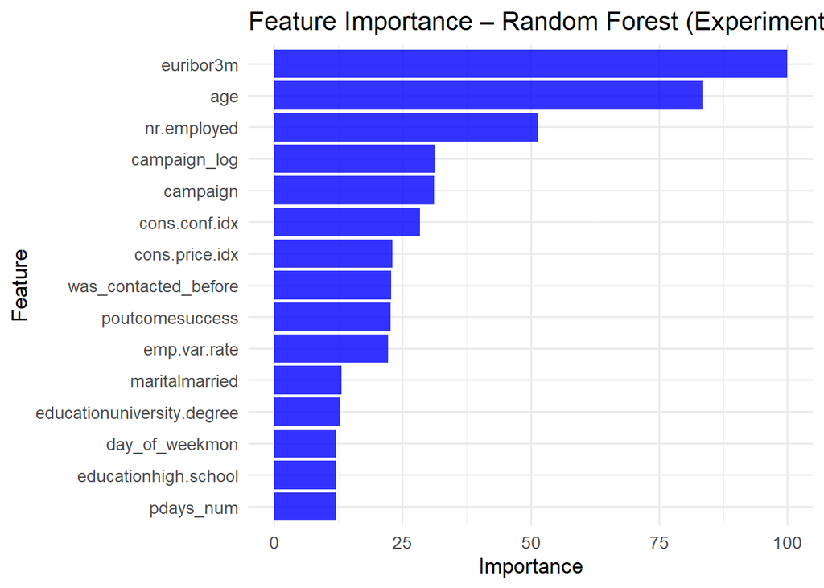

```r
# -----------------------------------------------------------
# Visualization for Experiment 2A – Baseline Random Forest
# -----------------------------------------------------------

library(ggplot2)
library(pROC)
library(caret)

# Variable Importance Plot
rf_imp <- varImp(model_rf_base)
rf_imp_df <- as.data.frame(rf_imp$importance)
rf_imp_df$Feature <- rownames(rf_imp_df)
rf_imp_df <- rf_imp_df %>%
  arrange(desc(Overall)) %>%
  head(15)  # show top 15 important features

ggplot(rf_imp_df, aes(x = reorder(Feature, Overall), y = Overall)) +
  geom_col(fill = "Blue", alpha = 0.8) +
  coord_flip() +
  theme_minimal(base_size = 13) +
  labs(
    title = "Feature Importance – Random Forest (Experiment 2A)",
    x = "Feature",
    y = "Importance"
  )
```

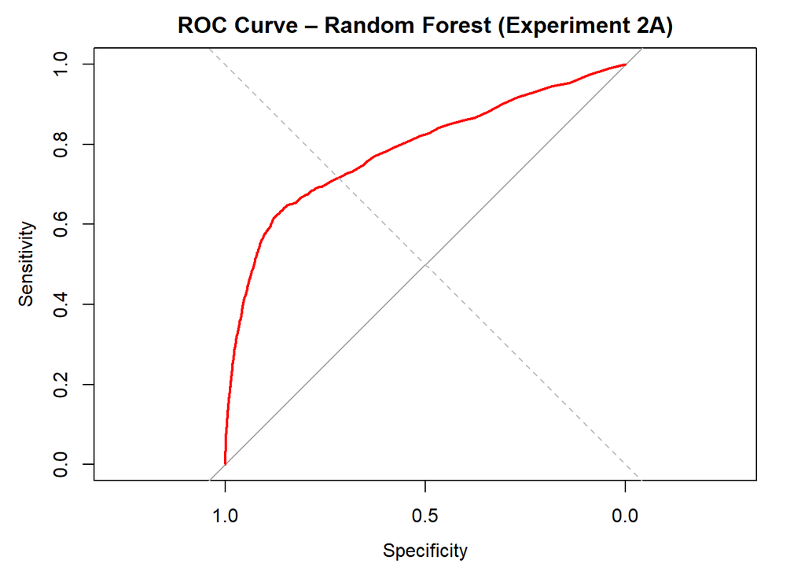

```r
# ROC Curve
roc_rf <- roc(test_rf$y, pred_rf_base_prob)
plot(roc_rf, col = "Red", lwd = 2, main = "ROC Curve – Random Forest (Experiment 2A)")
abline(a = 0, b = 1, lty = 2, col = "Grey")
```

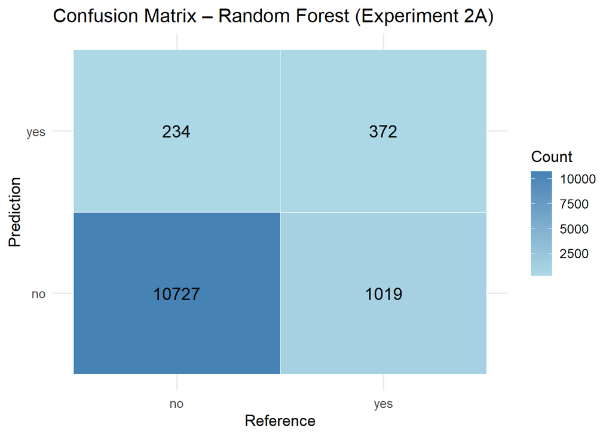

```r
# Confusion Matrix Visualization
cm_rf <- confusionMatrix(pred_rf_base_class, test_rf$y, positive = "yes")
cm_table <- as.data.frame(cm_rf$table)

ggplot(cm_table, aes(x = Reference, y = Prediction, fill = Freq)) +
  geom_tile(color = "white") +
  geom_text(aes(label = Freq), color = "black", size = 5) +
  scale_fill_gradient(low = "lightblue", high = "steelblue") +
  theme_minimal(base_size = 13) +
  labs(
    title = "Confusion Matrix – Random Forest (Experiment 2A)",
    fill = "Count"
  )
```

### Interpretation of Visualizations

**1. Feature Importance Plot**  
This plot highlights the most influential predictors in the Random Forest model.  
Variables with longer bars have a greater impact on classification outcomes.  
Notably, key economic indicators such as *euribor3m* and *nr.employed* exhibit strong influence, underscoring their significance in predicting client subscription behavior.

**2. ROC Curve**  
The Receiver Operating Characteristic (ROC) curve illustrates the trade-off between the **True Positive Rate (Recall)** and the **False Positive Rate (1 − Specificity)**.  
An Area Under the Curve (AUC) value of approximately **0.78** indicates good discriminatory ability.  
The farther the curve lies above the diagonal line, the more effectively the model distinguishes between positive and negative classes.

**3. Confusion Matrix Heatmap**  
This confusion matrix summarizes the prediction results of the baseline Random Forest model on the test dataset.

The color gradient reflects the **frequency of cases**, with darker cells showing higher counts.  
The large number of true negatives compared to true positives highlights the **class imbalance** in the dataset — the “no” class dominates, which explains the model’s bias toward predicting non-subscribers.

Overall, while the model achieves high **accuracy**, its **recall for the positive class** (subscribers) is relatively low, indicating that the Random Forest struggles to detect minority-class (“yes”) cases effectively in this baseline setup.

## 1.28 Experiment 2B – Tuned Random Forest (Cross-Validation)

### 1.28.1 Objective

This experiment aims to enhance the baseline Random Forest model’s ability to correctly identify clients who will subscribe to a term deposit.  
By tuning key hyperparameters and applying cross-validation, the goal is to improve the model’s **AUC** and **Recall**, thereby increasing its effectiveness in detecting minority (positive) cases.

### 1.28.3 Expected Outcome

Through hyperparameter tuning and cross-validation, the model is expected to achieve: - Higher **AUC**, indicating improved ability to distinguish between “yes” and “no” clients.  
- Increased **Recall**, capturing a larger proportion of actual positive cases.  
- A slight reduction in **Accuracy**, which is acceptable given the trade-off for better balance between classes.

## 1.29 Experiment 2B – Tuned Random Forest (Cross-Validation, Faster Version)

```r
# -----------------------------------------------------------
# Experiment 2B – Tuned Random Forest (Cross-Validation, Faster Version)
# -----------------------------------------------------------

library(caret)
library(randomForest)
library(pROC)
library(dplyr)
library(doParallel)

# --- Parallel Setup ---
cl <- makeCluster(parallel::detectCores() - 1)
registerDoParallel(cl)

# --- Data Preprocessing ---
pre_rf_tuned <- preProcess(train, method = c("medianImpute", "center", "scale"))
train_rf_tuned <- predict(pre_rf_tuned, newdata = train)
test_rf_tuned  <- predict(pre_rf_tuned, newdata = test)

# --- Cross-Validation ---
ctrl_rf_tuned <- trainControl(
  method = "cv",
  number = 3,                  # reduced from 5 to 3 folds
  classProbs = TRUE,
  summaryFunction = twoClassSummary
)

# --- Tuning Grid ---
grid_rf <- expand.grid(mtry = c(3, 5))   # reduced grid for speed

# --- Model Training ---
set.seed(123)
model_rf_tuned <- train(
  y ~ .,
  data = train_rf_tuned,
  method = "rf",
  trControl = ctrl_rf_tuned,
  tuneGrid = grid_rf,
  ntree = 150,                 # reduced from 500 to 150 trees
  metric = "ROC"
)

# --- Prediction & Evaluation ---
pred_rf_tuned_prob  <- predict(model_rf_tuned, newdata = test_rf_tuned, type = "prob")[, "yes"]
pred_rf_tuned_class <- ifelse(pred_rf_tuned_prob > 0.5, "yes", "no") %>%
  factor(levels = c("no", "yes"))

m_rf_tuned <- compute_metrics(test_rf_tuned$y, pred_rf_tuned_class, pred_rf_tuned_prob)
m_rf_tuned
```

```
## # A tibble: 1 × 5
##   Accuracy Precision Recall    F1   AUC
##      <dbl>     <dbl>  <dbl> <dbl> <dbl>
## 1    0.900     0.641  0.245 0.355 0.786
```

```r
# --- Log Result ---
log_result(
  alg = "Random Forest",
  exp_name = "RF-2B Tuned (Optimized)",
  change_desc = "3-fold CV, mtry={3,5}, ntree=150 (optimized runtime)",
  metrics_tbl = m_rf_tuned
)

# Stop parallel cluster
stopCluster(cl)
# View log
results_log
```

```
## # A tibble: 4 × 8
##   Algorithm     Experiment    What_Changed Accuracy Precision Recall    F1   AUC
##   <chr>         <chr>         <chr>           <dbl>     <dbl>  <dbl> <dbl> <dbl>
## 1 Decision Tree DT-1A Baseli… Baseline De…    0.899     0.713  0.170 0.274 0.708
## 2 Decision Tree DT-1B Tuned   Used SMOTE-…    0.812     0.858  0.719 0.782 0.843
## 3 Random Forest RF-2A Baseli… Default par…    0.899     0.614  0.267 0.373 0.787
## 4 Random Forest RF-2B Tuned … 3-fold CV, …    0.900     0.641  0.245 0.355 0.786
```

## 1.30 Interpretation of Experiment 2B – Tuned Random Forest (Cross-Validation)

| Metric | Value |
| --- | --- |
| **Accuracy** | 0.8995 |
| **Precision** | 0.6410 |
| **Recall** | 0.2451 |
| **F1-Score** | 0.3547 |
| **AUC** | 0.7864 |

### 1.30.1 Interpretation

The tuned Random Forest model (Experiment 2B) demonstrates performance similar to the baseline Random Forest (Experiment 2A), with only marginal improvements in precision but a slight decrease in recall.

- **Accuracy (0.8995)** remains almost unchanged from the baseline (0.8986), suggesting the overall classification ability is stable.
- **Precision (0.6410)** increased modestly, meaning that the model’s positive predictions are slightly more reliable.
- **Recall (0.2451)** decreased compared to 2A (0.2674), indicating that the tuned model identifies fewer actual positive cases.
- **F1-Score (0.3547)** shows a minor decline, reflecting the trade-off between higher precision and lower recall.
- **AUC (0.7864)** remains consistent with the baseline (0.7870), suggesting that tuning did not substantially change the model’s ability to distinguish between classes.

### 1.30.2 Overall Assessment

Despite implementing cross-validation and parameter tuning (`mtry={3,5}`, `ntree=150`), the tuned Random Forest did **not yield significant improvements** over the baseline.  
This result indicates that the default Random Forest configuration was already well-calibrated for this dataset.

Future improvements may focus on: - Applying **SMOTE or class weights** within the Random Forest to better handle class imbalance.  
- Expanding the tuning grid (e.g., exploring higher `mtry` or deeper trees).  
- Testing **alternative ensemble methods** such as AdaBoost or Gradient Boosting for enhanced recall and minority class detection.